# **Problem Statement**

## Business Context

Renewable energy sources play an increasingly important role in the global energy mix, as the effort to reduce the environmental impact of energy production increases.

Out of all the renewable energy alternatives, wind energy is one of the most developed technologies worldwide. The U.S Department of Energy has put together a guide to achieving operational efficiency using predictive maintenance practices.

Predictive maintenance uses sensor information and analysis methods to measure and predict degradation and future component capability. The idea behind predictive maintenance is that failure patterns are predictable and if component failure can be predicted accurately and the component is replaced before it fails, the costs of operation and maintenance will be much lower.

The sensors fitted across different machines involved in the process of energy generation collect data related to various environmental factors (temperature, humidity, wind speed, etc.) and additional features related to various parts of the wind turbine (gearbox, tower, blades, break, etc.).

## Objective

“ReneWind” is a company working on improving the machinery/processes involved in the production of wind energy using machine learning and has collected data of generator failure of wind turbines using sensors. They have shared a ciphered version of the data, as the data collected through sensors is confidential (the type of data collected varies with companies). Data has 40 predictors, 20000 observations in the training set and 5000 in the test set.

The objective is to build various classification models, tune them, and find the best one that will help identify failures so that the generators could be repaired before failing/breaking to reduce the overall maintenance cost. The nature of predictions made by the classification model will translate as follows:

- True positives (TP) are failures correctly predicted by the model. These will result in repairing costs.
- False negatives (FN) are real failures where there is no detection by the model. These will result in replacement costs.
- False positives (FP) are detections where there is no failure. These will result in inspection costs.

It is given that the cost of repairing a generator is much less than the cost of replacing it, and the cost of inspection is less than the cost of repair.

“1” in the target variables should be considered as “failure” and “0” represents “No failure”.

## Data Description

The data provided is a transformed version of the original data which was collected using sensors.

- Train.csv - To be used for training and tuning of models.
- Test.csv - To be used only for testing the performance of the final best model.

Both the datasets consist of 40 predictor variables and 1 target variable.

# **Installing and Importing the necessary libraries**

```python
# Installing the libraries with the specified version
!pip install --no-deps tensorflow==2.18.0 scikit-learn==1.3.2 matplotlib===3.8.3 seaborn==0.13.2 numpy==1.26.4 pandas==2.2.2 -q --user --no-warn-script-location
```

**Note**:

- After running the above cell, kindly restart the runtime (for Google Colab) or notebook kernel (for Jupyter Notebook), and run all cells sequentially from the next cell.
- On executing the above line of code, you might see a warning regarding package dependencies. This error message can be ignored as the above code ensures that all necessary libraries and their dependencies are maintained to successfully execute the code in **this notebook**.

```python
# Library for data manipulation and analysis.
import pandas as pd
# Fundamental package for scientific computing.
import numpy as np

#splitting datasets into training and testing sets.
from sklearn.model_selection import train_test_split
#Imports tools for data preprocessing including label encoding, one-hot encoding, and standard scaling
from sklearn.preprocessing import LabelEncoder, OneHotEncoder,StandardScaler
#Imports a class for imputing missing values in datasets.
from sklearn.impute import SimpleImputer
#Imports the Matplotlib library for creating visualizations.
from sklearn.metrics import confusion_matrix
import matplotlib.pyplot as plt
# Imports the Seaborn library for statistical data visualization.
import seaborn as sns
from IPython.display import display
# Time related functions.
import time
#Imports functions for evaluating the performance of machine learning models
from sklearn.metrics import confusion_matrix, f1_score,accuracy_score, recall_score, precision_score, classification_report
#Imports metrics from
from sklearn import metrics

#Imports the tensorflow,keras and layers.
import tensorflow
import tensorflow as tf
from tensorflow.keras.models import Sequential
from tensorflow.keras.layers import Dense, Input, Dropout,BatchNormalization
from tensorflow.keras import backend
from tensorflow.keras.metrics import Recall
from tensorflow.keras.optimizers import Adam
from tensorflow.keras.callbacks import EarlyStopping

# Set seeds
import os
import random
# Set threading configs BEFORE any TF init
tf.config.threading.set_inter_op_parallelism_threads(1)
tf.config.threading.set_intra_op_parallelism_threads(1)

# Set seeds
seed_value = 42
os.environ['PYTHONHASHSEED'] = str(seed_value)
os.environ['TF_DETERMINISTIC_OPS'] = '1'  # Optional: encourages determinism
random.seed(seed_value)
np.random.seed(seed_value)
tf.random.set_seed(seed_value)

# to suppress unnecessary warnings
import warnings
warnings.filterwarnings("ignore")
```

# **Loading the Data**

```python
# uncomment and run the following lines for Google Colab
from google.colab import drive
drive.mount('/content/drive')
```

```python
# Import the training and test data
df = pd.read_csv("/content/drive/MyDrive/Great Learning/4. Introduction to Neural Networks/Project - Introduction to Neural Networks: ReneWind/Train.csv")
df_test = pd.read_csv("/content/drive/MyDrive/Great Learning/4. Introduction to Neural Networks/Project - Introduction to Neural Networks: ReneWind/Test.csv")
```

```python
# Creating a copy of the training data
data = df.copy()
```

```python
# Creating a copy of the testing  data
data_test = df_test.copy()
```

Creating a copy of the training and testing datasets as data and data_test

# **Data Overview**

```python
# Checking the number of rows and columns in the training data
df.shape
```

```
(20000, 41)
```

#### **Comment:**

- The Training dataset has 20000 rows and 41 columns, indicating a moderately large sample with a reasonable number of features (40 predictors + 1 target).

```python
# Checking the number of rows and columns in the test data
df_test.shape
```

```
(5000, 41)
```

#### **Comment:**

- The Test dataset has 5000 rows and 41 columns, consistent with the structure of the training data.

#### View the first and last 5 rows of the dataset

```python
data.head()
```

|  | V1 | V2 | V3 | V4 | V5 | V6 | V7 | V8 | V9 | V10 | ... | V32 | V33 | V34 | V35 | V36 | V37 | V38 | V39 | V40 | Target |
| --- | --- | --- | --- | --- | --- | --- | --- | --- | --- | --- | --- | --- | --- | --- | --- | --- | --- | --- | --- | --- | --- |
| 0 | -4.464606 | -4.679129 | 3.101546 | 0.506130 | -0.221083 | -2.032511 | -2.910870 | 0.050714 | -1.522351 | 3.761892 | ... | 3.059700 | -1.690440 | 2.846296 | 2.235198 | 6.667486 | 0.443809 | -2.369169 | 2.950578 | -3.480324 | 0 |
| 1 | 3.365912 | 3.653381 | 0.909671 | -1.367528 | 0.332016 | 2.358938 | 0.732600 | -4.332135 | 0.565695 | -0.101080 | ... | -1.795474 | 3.032780 | -2.467514 | 1.894599 | -2.297780 | -1.731048 | 5.908837 | -0.386345 | 0.616242 | 0 |
| 2 | -3.831843 | -5.824444 | 0.634031 | -2.418815 | -1.773827 | 1.016824 | -2.098941 | -3.173204 | -2.081860 | 5.392621 | ... | -0.257101 | 0.803550 | 4.086219 | 2.292138 | 5.360850 | 0.351993 | 2.940021 | 3.839160 | -4.309402 | 0 |
| 3 | 1.618098 | 1.888342 | 7.046143 | -1.147285 | 0.083080 | -1.529780 | 0.207309 | -2.493629 | 0.344926 | 2.118578 | ... | -3.584425 | -2.577474 | 1.363769 | 0.622714 | 5.550100 | -1.526796 | 0.138853 | 3.101430 | -1.277378 | 0 |
| 4 | -0.111440 | 3.872488 | -3.758361 | -2.982897 | 3.792714 | 0.544960 | 0.205433 | 4.848994 | -1.854920 | -6.220023 | ... | 8.265896 | 6.629213 | -10.068689 | 1.222987 | -3.229763 | 1.686909 | -2.163896 | -3.644622 | 6.510338 | 0 |

5 rows × 41 columns

```python
data.tail()
```

|  | V1 | V2 | V3 | V4 | V5 | V6 | V7 | V8 | V9 | V10 | ... | V32 | V33 | V34 | V35 | V36 | V37 | V38 | V39 | V40 | Target |
| --- | --- | --- | --- | --- | --- | --- | --- | --- | --- | --- | --- | --- | --- | --- | --- | --- | --- | --- | --- | --- | --- |
| 19995 | -2.071318 | -1.088279 | -0.796174 | -3.011720 | -2.287540 | 2.807310 | 0.481428 | 0.105171 | -0.586599 | -2.899398 | ... | -8.273996 | 5.745013 | 0.589014 | -0.649988 | -3.043174 | 2.216461 | 0.608723 | 0.178193 | 2.927755 | 1 |
| 19996 | 2.890264 | 2.483069 | 5.643919 | 0.937053 | -1.380870 | 0.412051 | -1.593386 | -5.762498 | 2.150096 | 0.272302 | ... | -4.159092 | 1.181466 | -0.742412 | 5.368979 | -0.693028 | -1.668971 | 3.659954 | 0.819863 | -1.987265 | 0 |
| 19997 | -3.896979 | -3.942407 | -0.351364 | -2.417462 | 1.107546 | -1.527623 | -3.519882 | 2.054792 | -0.233996 | -0.357687 | ... | 7.112162 | 1.476080 | -3.953710 | 1.855555 | 5.029209 | 2.082588 | -6.409304 | 1.477138 | -0.874148 | 0 |
| 19998 | -3.187322 | -10.051662 | 5.695955 | -4.370053 | -5.354758 | -1.873044 | -3.947210 | 0.679420 | -2.389254 | 5.456756 | ... | 0.402812 | 3.163661 | 3.752095 | 8.529894 | 8.450626 | 0.203958 | -7.129918 | 4.249394 | -6.112267 | 0 |
| 19999 | -2.686903 | 1.961187 | 6.137088 | 2.600133 | 2.657241 | -4.290882 | -2.344267 | 0.974004 | -1.027462 | 0.497421 | ... | 6.620811 | -1.988786 | -1.348901 | 3.951801 | 5.449706 | -0.455411 | -2.202056 | 1.678229 | -1.974413 | 0 |

5 rows × 41 columns

#### **Comment:**

- I quickly inspect a few sample rows at the top and bottom to confirm column names, data types, and see if there are any immediately obvious issues

```python
#Number of distinct categories or classes i.e., Fraudulent and Genuine
data['Target'].nunique()
```

```
2
```

#### **Comment:**

- The target variable contains 2 distinct classes, confirming that this is a binary classification problem.

#### Checking the data types of the columns in the dataset

```python
# Checking the data types of the columns in the train data
data.info()
```

```
<class 'pandas.core.frame.DataFrame'>
RangeIndex: 20000 entries, 0 to 19999
Data columns (total 41 columns):
 #   Column  Non-Null Count  Dtype
---  ------  --------------  -----
 0   V1      19982 non-null  float64
 1   V2      19982 non-null  float64
 2   V3      20000 non-null  float64
 3   V4      20000 non-null  float64
 4   V5      20000 non-null  float64
 5   V6      20000 non-null  float64
 6   V7      20000 non-null  float64
 7   V8      20000 non-null  float64
 8   V9      20000 non-null  float64
 9   V10     20000 non-null  float64
```

[output cut: 33 more lines]

#### **Comment:**

- There are missing values in V1 and V2 (18 missing each), while all other features are complete. Overall, the dataset is well-structured and suitable for machine learning, but missing values in V1 and V2 will be addressed later in the project via imputation.

Converting Target column to float

```python
data['Target'] = data['Target'].astype(float)
```

#### **Comment:**

- This converts the Target for the training data column from int64 to float64. This is necessary for compatibility with certain machine learning frameworks (e.g., Keras/TensorFlow) that expect both features and labels to be floating-point values during training.

Checking for test data

```python
# Checking the data types of the columns in the test data
data_test.info()
```

```
<class 'pandas.core.frame.DataFrame'>
RangeIndex: 5000 entries, 0 to 4999
Data columns (total 41 columns):
 #   Column  Non-Null Count  Dtype
---  ------  --------------  -----
 0   V1      4995 non-null   float64
 1   V2      4994 non-null   float64
 2   V3      5000 non-null   float64
 3   V4      5000 non-null   float64
 4   V5      5000 non-null   float64
 5   V6      5000 non-null   float64
 6   V7      5000 non-null   float64
 7   V8      5000 non-null   float64
 8   V9      5000 non-null   float64
 9   V10     5000 non-null   float64
```

[output cut: 33 more lines]

#### **Comment:**

- Missing Values: Two columns, V1 and V2, have 5 and 6 missing entries respectively (4995 and 4994 non-null out of 5000). All other columns are complete with 5000 non-null values.
- Data Types: All features (V1 to V40) are of type float64, and the Target variable is of type int64, indicating a binary classification setup.

Converting Target to float

```python
data_test['Target'] = data_test['Target'].astype(float)
```

#### **Comment:**

- This converts the Target for the test data column from int64 to float64. This is necessary for compatibility with certain machine learning frameworks (e.g., Keras/TensorFlow) that expect both features and labels to be floating-point values during training.

## Checking for duplicate values

```python
# Checking for duplicate values in the train data
data.duplicated().sum()
```

```
0
```

```python
# Checking for duplicate values in the test data
data_test.duplicated().sum()
```

```
0
```

#### **Comment:**

- No duplicate records were found in both the training and test datasets

## Checking for missing values

```python
# Checking for missing values in the data
data.isnull().sum()
```

|  | 0 |
| --- | --- |
| V1 | 18 |
| V2 | 18 |
| V3 | 0 |
| V4 | 0 |
| V5 | 0 |
| V6 | 0 |
| V7 | 0 |
| V8 | 0 |
| V9 | 0 |
| V10 | 0 |
| V11 | 0 |
| V12 | 0 |
| V13 | 0 |
| V14 | 0 |
| V15 | 0 |
| V16 | 0 |
| V17 | 0 |
| V18 | 0 |
| V19 | 0 |
| V20 | 0 |
| V21 | 0 |
| V22 | 0 |
| V23 | 0 |
| V24 | 0 |
| V25 | 0 |
| V26 | 0 |
| V27 | 0 |
| V28 | 0 |
| V29 | 0 |
| V30 | 0 |
| V31 | 0 |
| V32 | 0 |
| V33 | 0 |
| V34 | 0 |
| V35 | 0 |
| V36 | 0 |
| V37 | 0 |
| V38 | 0 |
| V39 | 0 |
| V40 | 0 |
| Target | 0 |

**dtype:** int64

#### **Comment:**

```python
# Checking for missing values in the test data
data_test.isnull().sum()
```

|  | 0 |
| --- | --- |
| V1 | 5 |
| V2 | 6 |
| V3 | 0 |
| V4 | 0 |
| V5 | 0 |
| V6 | 0 |
| V7 | 0 |
| V8 | 0 |
| V9 | 0 |
| V10 | 0 |
| V11 | 0 |
| V12 | 0 |
| V13 | 0 |
| V14 | 0 |
| V15 | 0 |
| V16 | 0 |
| V17 | 0 |
| V18 | 0 |
| V19 | 0 |
| V20 | 0 |
| V21 | 0 |
| V22 | 0 |
| V23 | 0 |
| V24 | 0 |
| V25 | 0 |
| V26 | 0 |
| V27 | 0 |
| V28 | 0 |
| V29 | 0 |
| V30 | 0 |
| V31 | 0 |
| V32 | 0 |
| V33 | 0 |
| V34 | 0 |
| V35 | 0 |
| V36 | 0 |
| V37 | 0 |
| V38 | 0 |
| V39 | 0 |
| V40 | 0 |
| Target | 0 |

**dtype:** int64

## Statistical summary of the dataset

```python
# Statistical summary of the numerical columns in the data
data.describe().T
```

|  | count | mean | std | min | 25% | 50% | 75% | max |
| --- | --- | --- | --- | --- | --- | --- | --- | --- |
| V1 | 19982.0 | -0.271996 | 3.441625 | -11.876451 | -2.737146 | -0.747917 | 1.840112 | 15.493002 |
| V2 | 19982.0 | 0.440430 | 3.150784 | -12.319951 | -1.640674 | 0.471536 | 2.543967 | 13.089269 |
| V3 | 20000.0 | 2.484699 | 3.388963 | -10.708139 | 0.206860 | 2.255786 | 4.566165 | 17.090919 |
| V4 | 20000.0 | -0.083152 | 3.431595 | -15.082052 | -2.347660 | -0.135241 | 2.130615 | 13.236381 |
| V5 | 20000.0 | -0.053752 | 2.104801 | -8.603361 | -1.535607 | -0.101952 | 1.340480 | 8.133797 |
| V6 | 20000.0 | -0.995443 | 2.040970 | -10.227147 | -2.347238 | -1.000515 | 0.380330 | 6.975847 |
| V7 | 20000.0 | -0.879325 | 1.761626 | -7.949681 | -2.030926 | -0.917179 | 0.223695 | 8.006091 |
| V8 | 20000.0 | -0.548195 | 3.295756 | -15.657561 | -2.642665 | -0.389085 | 1.722965 | 11.679495 |
| V9 | 20000.0 | -0.016808 | 2.160568 | -8.596313 | -1.494973 | -0.067597 | 1.409203 | 8.137580 |
| V10 | 20000.0 | -0.012998 | 2.193201 | -9.853957 | -1.411212 | 0.100973 | 1.477045 | 8.108472 |
| V11 | 20000.0 | -1.895393 | 3.124322 | -14.832058 | -3.922404 | -1.921237 | 0.118906 | 11.826433 |
| V12 | 20000.0 | 1.604825 | 2.930454 | -12.948007 | -0.396514 | 1.507841 | 3.571454 | 15.080698 |
| V13 | 20000.0 | 1.580486 | 2.874658 | -13.228247 | -0.223545 | 1.637185 | 3.459886 | 15.419616 |
| V14 | 20000.0 | -0.950632 | 1.789651 | -7.738593 | -2.170741 | -0.957163 | 0.270677 | 5.670664 |
| V15 | 20000.0 | -2.414993 | 3.354974 | -16.416606 | -4.415322 | -2.382617 | -0.359052 | 12.246455 |
| V16 | 20000.0 | -2.925225 | 4.221717 | -20.374158 | -5.634240 | -2.682705 | -0.095046 | 13.583212 |
| V17 | 20000.0 | -0.134261 | 3.345462 | -14.091184 | -2.215611 | -0.014580 | 2.068751 | 16.756432 |
| V18 | 20000.0 | 1.189347 | 2.592276 | -11.643994 | -0.403917 | 0.883398 | 2.571770 | 13.179863 |
| V19 | 20000.0 | 1.181808 | 3.396925 | -13.491784 | -1.050168 | 1.279061 | 3.493299 | 13.237742 |
| V20 | 20000.0 | 0.023608 | 3.669477 | -13.922659 | -2.432953 | 0.033415 | 2.512372 | 16.052339 |
| V21 | 20000.0 | -3.611252 | 3.567690 | -17.956231 | -5.930360 | -3.532888 | -1.265884 | 13.840473 |
| V22 | 20000.0 | 0.951835 | 1.651547 | -10.122095 | -0.118127 | 0.974687 | 2.025594 | 7.409856 |
| V23 | 20000.0 | -0.366116 | 4.031860 | -14.866128 | -3.098756 | -0.262093 | 2.451750 | 14.458734 |
| V24 | 20000.0 | 1.134389 | 3.912069 | -16.387147 | -1.468062 | 0.969048 | 3.545975 | 17.163291 |
| V25 | 20000.0 | -0.002186 | 2.016740 | -8.228266 | -1.365178 | 0.025050 | 1.397112 | 8.223389 |
| V26 | 20000.0 | 1.873785 | 3.435137 | -11.834271 | -0.337863 | 1.950531 | 4.130037 | 16.836410 |
| V27 | 20000.0 | -0.612413 | 4.368847 | -14.904939 | -3.652323 | -0.884894 | 2.189177 | 17.560404 |
| V28 | 20000.0 | -0.883218 | 1.917713 | -9.269489 | -2.171218 | -0.891073 | 0.375884 | 6.527643 |
| V29 | 20000.0 | -0.985625 | 2.684365 | -12.579469 | -2.787443 | -1.176181 | 0.629773 | 10.722055 |
| V30 | 20000.0 | -0.015534 | 3.005258 | -14.796047 | -1.867114 | 0.184346 | 2.036229 | 12.505812 |
| V31 | 20000.0 | 0.486842 | 3.461384 | -13.722760 | -1.817772 | 0.490304 | 2.730688 | 17.255090 |
| V32 | 20000.0 | 0.303799 | 5.500400 | -19.876502 | -3.420469 | 0.052073 | 3.761722 | 23.633187 |
| V33 | 20000.0 | 0.049825 | 3.575285 | -16.898353 | -2.242857 | -0.066249 | 2.255134 | 16.692486 |
| V34 | 20000.0 | -0.462702 | 3.183841 | -17.985094 | -2.136984 | -0.255008 | 1.436935 | 14.358213 |
| V35 | 20000.0 | 2.229620 | 2.937102 | -15.349803 | 0.336191 | 2.098633 | 4.064358 | 15.291065 |
| V36 | 20000.0 | 1.514809 | 3.800860 | -14.833178 | -0.943809 | 1.566526 | 3.983939 | 19.329576 |
| V37 | 20000.0 | 0.011316 | 1.788165 | -5.478350 | -1.255819 | -0.128435 | 1.175533 | 7.467006 |
| V38 | 20000.0 | -0.344025 | 3.948147 | -17.375002 | -2.987638 | -0.316849 | 2.279399 | 15.289923 |
| V39 | 20000.0 | 0.890653 | 1.753054 | -6.438880 | -0.272250 | 0.919261 | 2.057540 | 7.759877 |
| V40 | 20000.0 | -0.875630 | 3.012155 | -11.023935 | -2.940193 | -0.920806 | 1.119897 | 10.654265 |
| Target | 20000.0 | 0.055500 | 0.228959 | 0.000000 | 0.000000 | 0.000000 | 0.000000 | 1.000000 |

#### **Comment:**

# **Exploratory Data Analysis**

## Univariate analysis

```python
# function to plot a boxplot and a histogram along the same scale.


def histogram_boxplot(data, feature, figsize=(12, 7), kde=False, bins=None):
    """
    Boxplot and histogram combined

    data: dataframe
    feature: dataframe column
    figsize: size of figure (default (12,7))
    kde: whether to the show density curve (default False)
    bins: number of bins for histogram (default None)
    """
    f2, (ax_box2, ax_hist2) = plt.subplots(
        nrows=2,  # Number of rows of the subplot grid= 2
        sharex=True,  # x-axis will be shared among all subplots
        gridspec_kw={"height_ratios": (0.25, 0.75)},
        figsize=figsize,
    )  # creating the 2 subplots
    sns.boxplot(
        data= data, x= feature, ax= ax_box2, showmeans=True, color="violet"
    )  # boxplot will be created and a star will indicate the mean value of the column
    sns.histplot(
        data=data, x=feature, kde=kde, ax=ax_hist2, bins=bins, palette="winter"
    ) if bins else sns.histplot(
        data=data, x=feature, kde=kde, ax=ax_hist2
    )  # For histogram
    ax_hist2.axvline(
        data[feature].mean(), color="green", linestyle="--"
    )  # Add mean to the histogram
    ax_hist2.axvline(
        data[feature].median(), color="black", linestyle="-"
    )  # Add median to the histogram
```

### Histogram and Boxplot of the variables

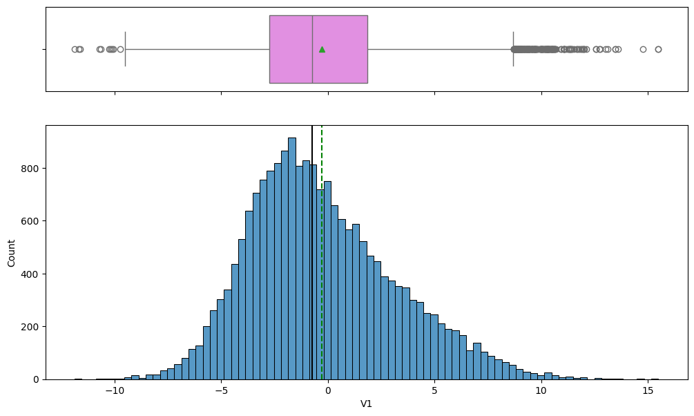

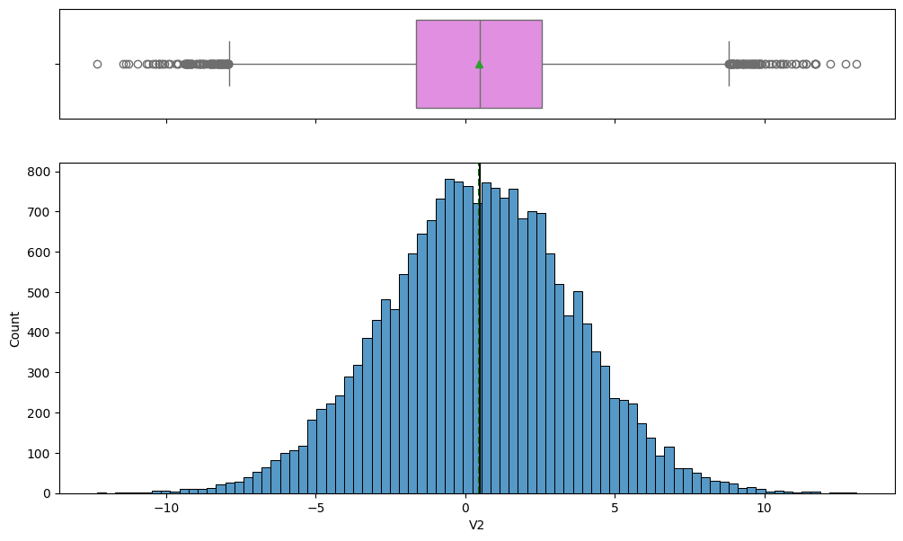

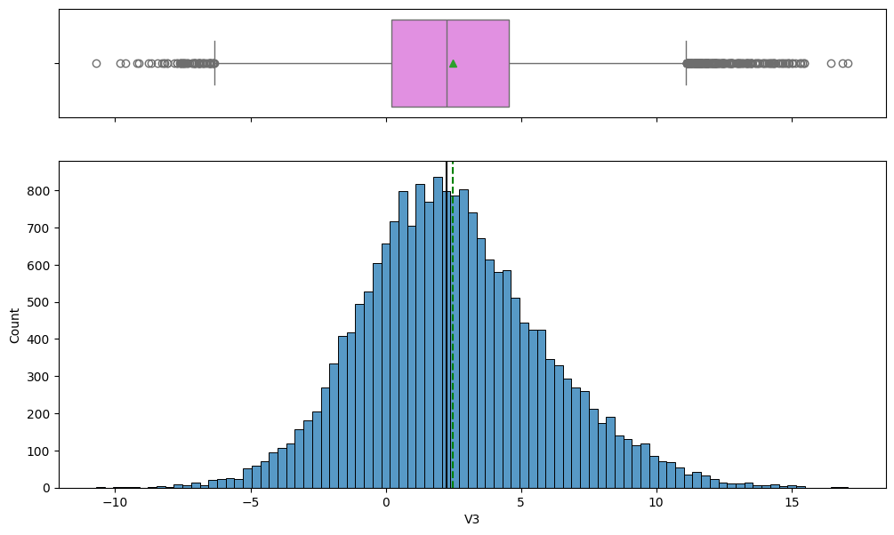

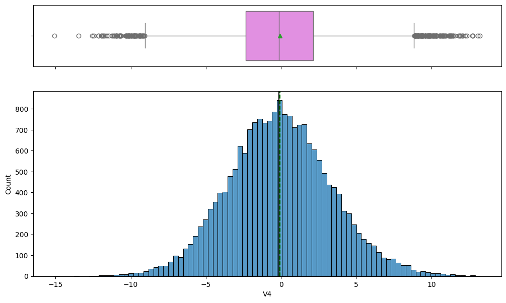

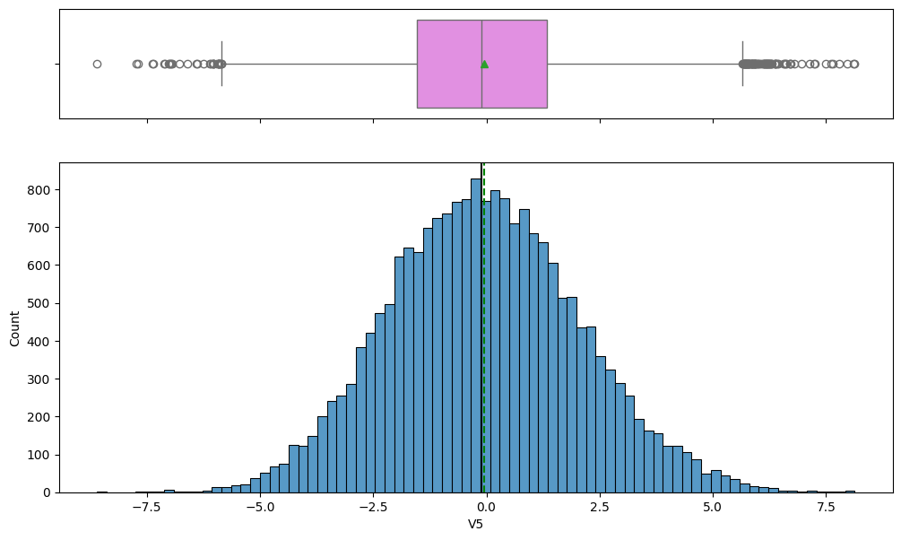

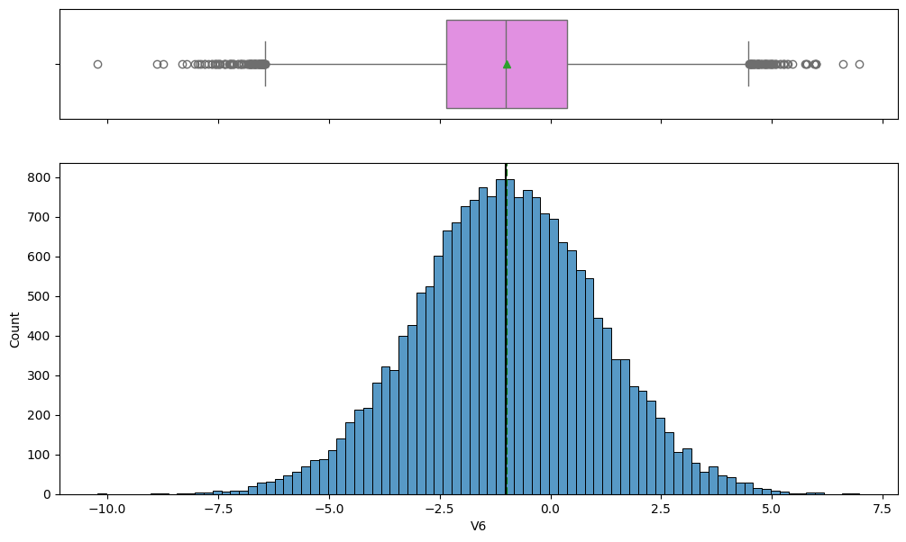

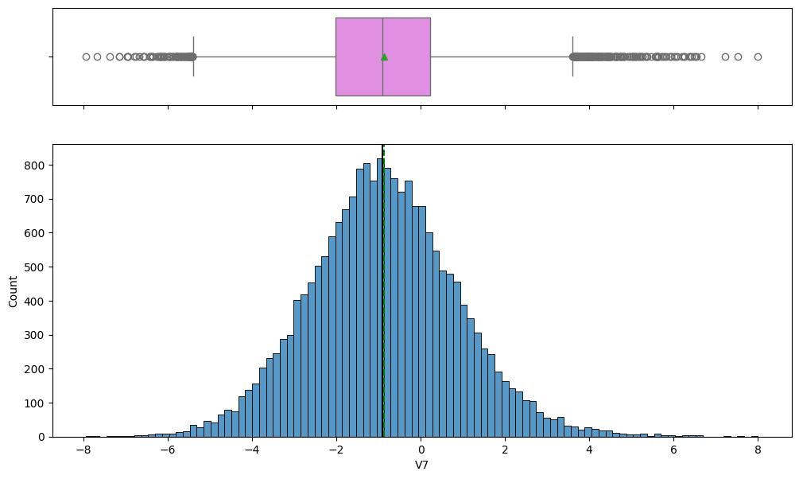

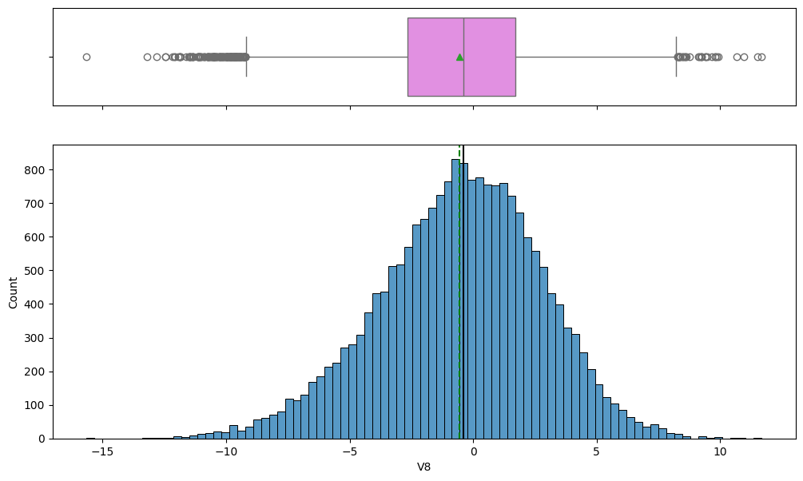

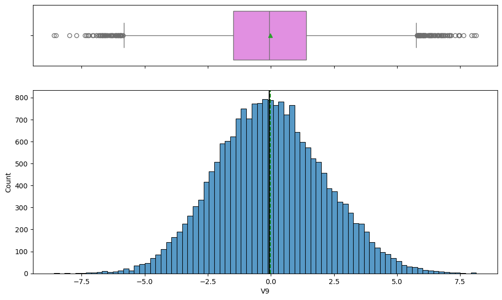

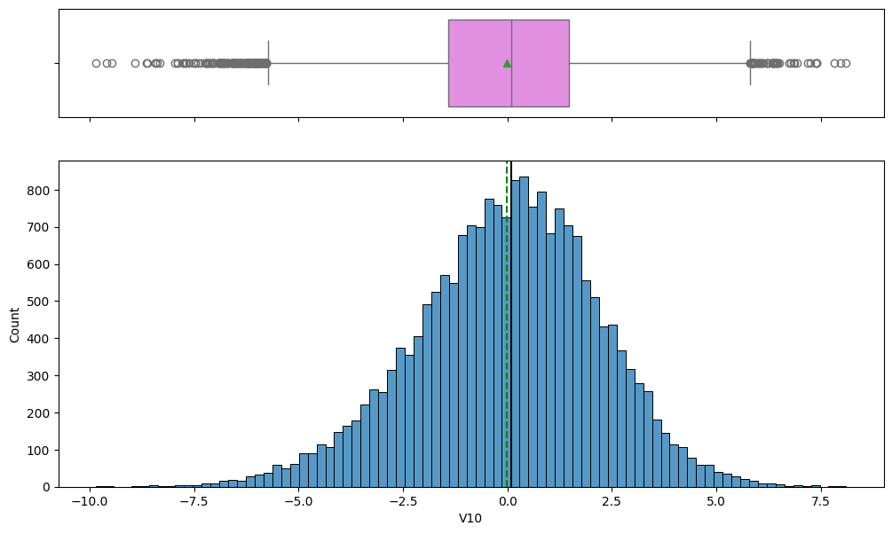

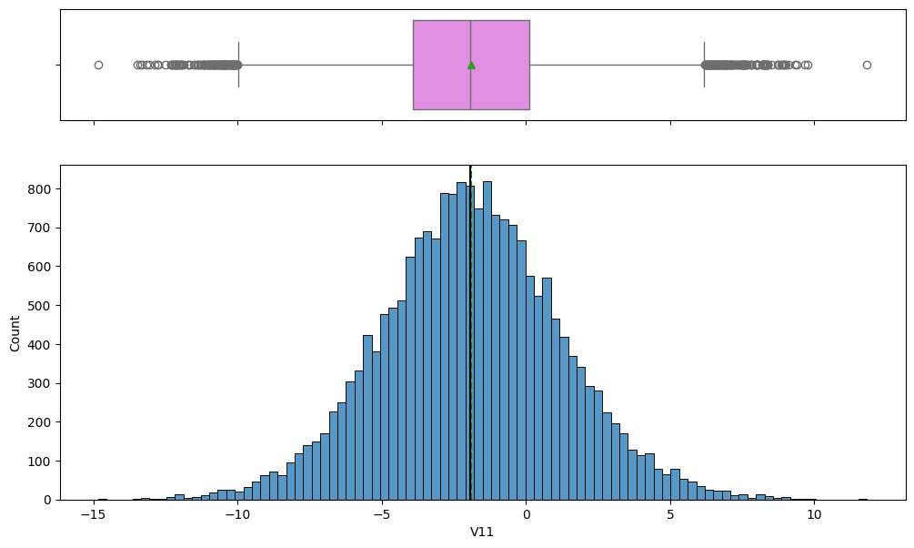

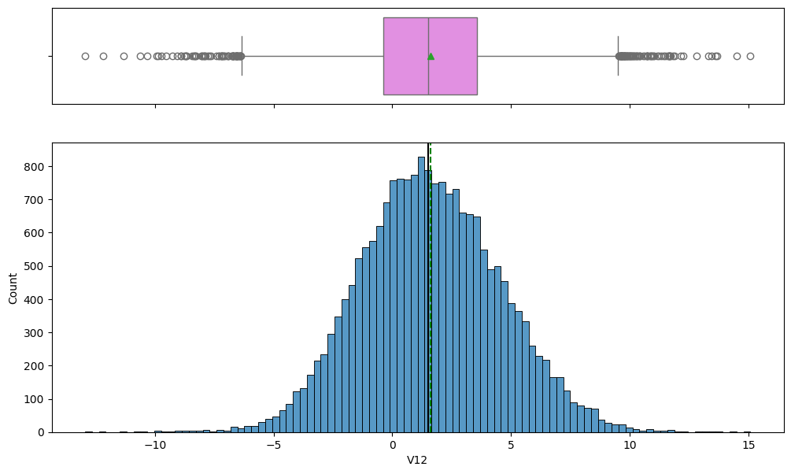

[29 more figures not shown]

```python
for feature in df.columns:
    histogram_boxplot(df, feature, figsize=(12, 7), kde=False, bins=None)
```

### Checking the distrubution of Target variable

```python
# For train data
df["Target"].value_counts(1)
```

| Target | proportion |
| --- | --- |
| 0 | 0.9445 |
| 1 | 0.0555 |

**dtype:** float64

```python
# For test data
df_test["Target"].value_counts(1)
```

| Target | proportion |
| --- | --- |
| 0 | 0.9436 |
| 1 | 0.0564 |

**dtype:** float64

#### **Comment:**

- The dataset exhibits extreme class imbalance, which can cause a neural network to favor the majority class (No Failure) during training.
- To mitigate this, your current strategies like:
  - Using class_weight in model training,
  - Focusing on recall as the key performance metric,
  - Employing dropout, batch normalization, and custom architectures

These will help the model generalize well and detect rare failure events effectively.

## Bivariate Analysis

**Correlation of Features with Failure Outcome**

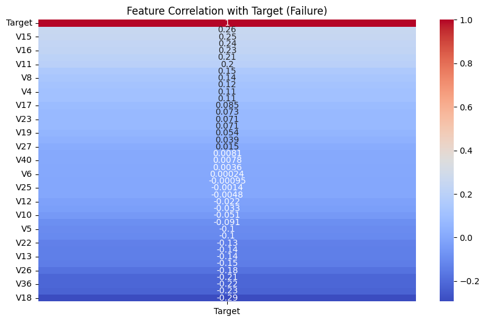

```python
# Combine features and target from the full dataset for correlation analysis
corr_matrix = data.corr(numeric_only=True)

# Plot correlations with the target
plt.figure(figsize=(10, 6))
sns.heatmap(corr_matrix[["Target"]].sort_values("Target", ascending=False), annot=True, cmap='coolwarm')
plt.title("Feature Correlation with Target (Failure)")
plt.show()
```

#### **Comment:**

**Pairplot of Selected Features Colored by Class**

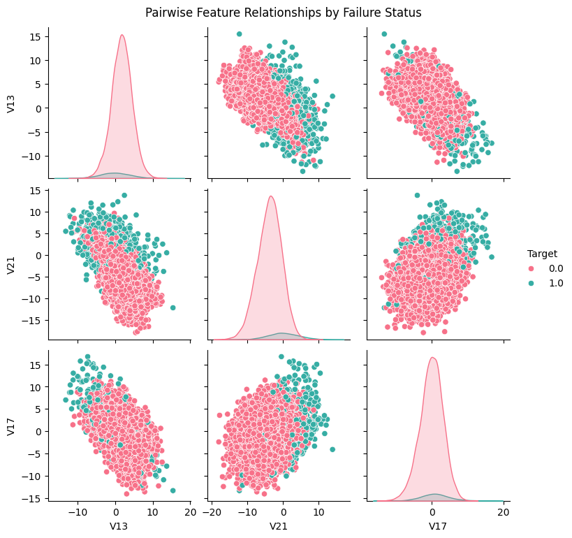

```python
top_features = ['V13', 'V21', 'V17']  # Replace with actual top 3 from feature importance

# Create DataFrame with top 3 features and target
pair_df = data[top_features + ["Target"]].copy()

# Plot pairwise relationships
sns.pairplot(pair_df, hue="Target", palette="husl", diag_kind="kde")
plt.suptitle("Pairwise Feature Relationships by Failure Status", y=1.02)
plt.show()
```

#### **Comment:**

- V13 and V21: These features show a strong negative linear relationship, with failure cases (Target = 1, green) tending to cluster in different regions than non-failure (Target = 0, pink). This suggests potential discriminative power.
- V13 and V17: A weaker negative relationship is observed, but the classes appear more overlapping, indicating limited separation capacity between failure and non-failure classes.
- V21 and V17: Displays a mild positive correlation, with slightly better separation of the target classes compared to V13-V17. Failures tend to concentrate around a different region.
- Diagonal KDE plots: Distributions for features like V13 and V21 show differing density curves by target class—further supporting their relevance in classification tasks.
- Overall, V13 and V21 show promising patterns for distinguishing failure, potentially useful in feature selection or importance analysis.

**Violin Plots (Distribution by Class)**

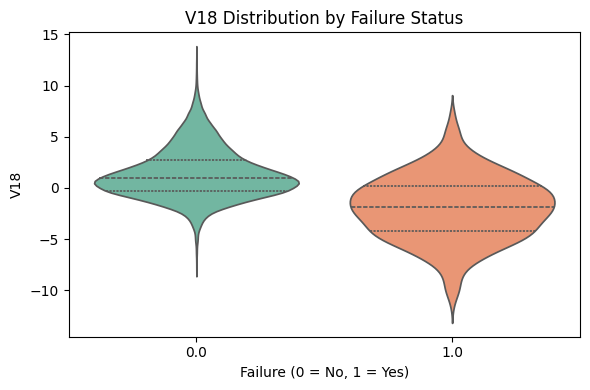

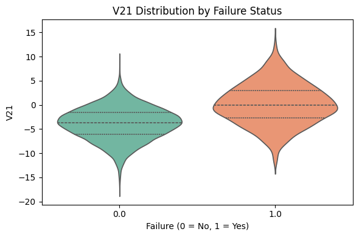

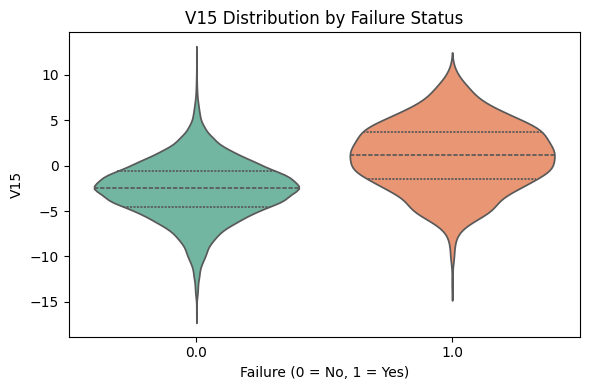

```python
# Choose top 3 correlated features for visualization
top_features = corr_matrix["Target"].abs().sort_values(ascending=False)[1:4].index  # skip 'Target' itself

# Violin plots of top correlated features grouped by target
for feature in top_features:
    plt.figure(figsize=(6, 4))
    sns.violinplot(x="Target", y=feature, data=data, palette="Set2", inner="quart")
    plt.title(f"{feature} Distribution by Failure Status")
    plt.xlabel("Failure (0 = No, 1 = Yes)")
    plt.ylabel(feature)
    plt.tight_layout()
    plt.show()
```

#### **Comment:**

Summary of the violin plots showing the distribution of the top 3 most correlated features (V18, V21, and V15) by failure status

- V18
  - Trend: Failed turbines (Target = 1) have lower V18 values.
  - Separation: Clear separation between failure classes.
  - Value: High predictive potential due to distribution shift.
- V21
  - Trend: Failed turbines show higher V21 values, while non-failed ones cluster around negative values.
  - Separation: Strong visible shift in central tendency between classes.
  - Value: Distinct feature for class differentiation.
- V15
  - Trend: Turbines that failed tend to have higher V15 values.
  - Separation: Clear distributional difference between the two groups.
  - Value: Useful for identifying potential turbine failures.

### Correlation Check

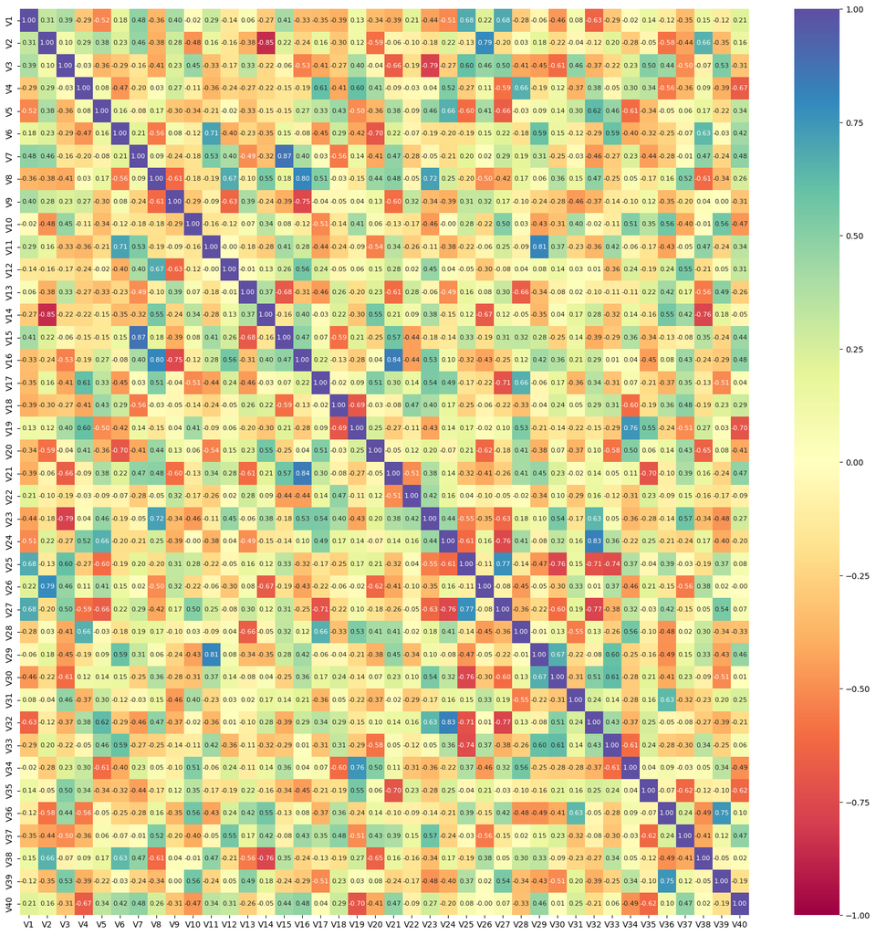

```python
cols_list = df.select_dtypes(include=np.number).columns.tolist()
cols_list.remove("Target")

plt.figure(figsize=(20, 20))
sns.heatmap(
    df[cols_list].corr(),
    annot=True,
    annot_kws={"size": 8},  # Set font size here
    vmin=-1,
    vmax=1,
    fmt=".2f",
    cmap="Spectral"
)
plt.show()
```

#### **Comment:**

# **Data Preprocessing**

### Data Preparation for Modeling

```python
# Dividing train data into X and y
X = data.drop(columns = ["Target"] , axis=1)
y = data["Target"]
```

#### **Comment:**

- The dataset is split into predictors (X) and the target (y), enabling the neural network to learn failure patterns based on input signals while keeping the target variable isolated for supervision and evaluation.

**Since we already have a separate test set, we don't need to divide data into train, valiation and test**

```python
# Splitting data into training and validation set:

X_train, X_val, y_train, y_val = train_test_split(
    X, y, test_size=0.2, random_state=1, stratify=y
)
```

#### **Comment:**

- The training data is split into 80% for training and 20% for validation using stratified sampling to preserve the original class imbalance (≈5.5% failures). This helps ensure fair model evaluation and reduces bias due to skewed target distribution.

```python
# Checking the number of rows and columns in the X_train data
X_train.shape

# Checking the number of rows and columns in the X_val data
X_val.shape
```

```
(4000, 40)
```

#### **Comment:**

- The training set contains 16,000 rows and 40 features, while the validation set has 4,000 rows and the same 40 features—confirming a successful 80/20 stratified split of the 20,000 original samples.

```python
# Dividing test data into X_test and y_test

X_test = data_test.drop(columns = ["Target"] , axis=1)
y_test = data_test["Target"]
```

#### **Comment:**

- The test dataset was successfully split into X_test (features) and y_test (target), maintaining consistency with the train/validation structure for model evaluation after training.

```python
# Checking the number of rows and columns in the X_test data
X_test.shape
```

```
(5000, 40)
```

#### **Comment:**

- The test feature set X_test contains 5,000 rows and 40 columns, confirming it matches the expected partition size and structure from earlier steps.

## Missing Value Imputation

- There were few missing values in V1 and V2, we will impute them using the median.
- And to avoid data leakage we will impute missing values after splitting train data into train and validation sets.

```python
imputer = SimpleImputer(strategy="median")
```

```python
# Fit and transform the train data
X_train = pd.DataFrame(imputer.fit_transform(X_train), columns=X_train.columns)

# Transform the validation data
X_val = pd.DataFrame(imputer.transform(X_val), columns=X_train.columns)

# Transform the test data
X_test = pd.DataFrame(imputer.transform(X_test), columns=X_train.columns)
```

- Missing Value Treatment:
  - A SimpleImputer with median strategy is applied, ensuring that missing numerical values are filled robustly—less sensitive to extreme outliers than the mean.
  - The imputer is fitted only on X_train, which avoids data leakage, and the same transformation is consistently applied to X_val and X_test.
  - All transformed datasets retain original feature names using columns=X_train.columns, preserving alignment across modeling stages.

```python
# Checking that no column has missing values in train or test sets
print(X_train.isna().sum())
print("-" * 30)
print(X_val.isna().sum())
print("-" * 30)
print(X_test.isna().sum())
```

```
V1     0
V2     0
V3     0
V4     0
V5     0
V6     0
V7     0
V8     0
V9     0
V10    0
V11    0
V12    0
V13    0
V14    0
V15    0
V16    0
V17    0
V18    0
V19    0
V20    0
V21    0
V22    0
V23    0
V24    0
V25    0
V26    0
V27    0
V28    0
V29    0
V30    0
V31    0
V32    0
V33    0
V34    0
V35    0
V36    0
V37    0
V38    0
V39    0
V40    0
```

[output cut: 70 more lines]

```
V27    0
V28    0
V29    0
V30    0
V31    0
V32    0
V33    0
V34    0
V35    0
V36    0
V37    0
V38    0
V39    0
V40    0
dtype: int64
```

#### **Comment:**

- After applying median imputation using SimpleImputer, all 40 features (V1–V40) in the training, validation, and test datasets show 0 missing values per column.
- This confirms that the imputation step was successfully applied across all splits, ensuring data integrity for model training and evaluation.
- This step is especially critical for neural networks, which do not natively handle NaN values and require complete data.

```python
y_train = y_train.to_numpy()
y_val = y_val.to_numpy()
y_test = y_test.to_numpy()
```

#### **Comment:**

- The y_train, y_val, and y_test series were converted to NumPy arrays.
- This is necessary for compatibility with most deep learning frameworks (like Keras or TensorFlow), which expect inputs in NumPy format.

# **Model Building**

## Model Evaluation Criterion

```python
def plot(history, name):
    """
    Function to plot loss/accuracy

    history: an object which stores the metrics and losses.
    name: can be one of Loss or Accuracy
    """
    fig, ax = plt.subplots() #Creating a subplot with figure and axes.
    plt.plot(history.history[name]) #Plotting the train accuracy or train loss
    plt.plot(history.history['val_'+name]) #Plotting the validation accuracy or validation loss

    plt.title('Model ' + name.capitalize()) #Defining the title of the plot.
    plt.ylabel(name.capitalize()) #Capitalizing the first letter.
    plt.xlabel('Epoch') #Defining the label for the x-axis.
    fig.legend(['Train', 'Validation'], loc="outside right upper") #Defining the legend, loc controls the position of the legend.
```

#### **Comment:**

- Visualization Function (plot):
  - Plots training and validation trends for loss or accuracy.
  - Useful for detecting overfitting (e.g., rising validation loss while training loss drops) or underfitting (both losses remain high).
  - X-axis: Epochs, while Y-axis: Selected metric (Loss/Accuracy).

```python
# defining a function to compute different metrics to check performance of a classification model built using statsmodels
def model_performance_classification(model, predictors, target, threshold=0.5):
    """
    Evaluate binary classification model with emphasis on recall.

    Parameters:
    - model: trained model
    - predictors: input features
    - target: true binary labels
    - threshold: probability cutoff for positive class prediction

    Returns:
    - DataFrame with Recall, Precision, F1 Score, and Accuracy
    """

    # Get predictions using threshold
    prob_pred = model.predict(predictors)
    pred = (prob_pred > threshold).astype(int)

    # Compute metrics
    recall = recall_score(target, pred)            # Focus on class '1' by default
    precision = precision_score(target, pred)
    f1 = f1_score(target, pred)
    acc = accuracy_score(target, pred)

    # Return metrics with recall first
    return pd.DataFrame({
        "Recall (Priority)": [recall],
        "Precision": [precision],
        "F1 Score": [f1],
        "Accuracy": [acc]
    })
```

#### **Comment:**

- This Performance function returns four core metrics:
  - Recall (Priority) – prioritized due to high business cost of missing failures.
  - Precision – indicates inspection efficiency.
  - F1 Score – balance between recall and precision.
  - Accuracy – general performance, though less useful in imbalanced scenarios.
- It works with probabilistic outputs from the neural network and uses a threshold (default 0.5) to convert to binary predictions.

```python
#Defining the columns of the dataframe which are nothing but the hyper parameters and the metrics.
columns = ["# hidden layers","# neurons - hidden layer","activation function - hidden layer ","# epochs","batch size","optimizer","learning rate, momentum","weight initializer","regularization","train loss","validation loss","train recall","validation recall","time (secs)"]

#Creating a pandas dataframe.
results = pd.DataFrame(columns=columns)
```

#### **Comment:**

- This helps to generates a structured DataFrame to log and compare neural network experiments by capturing both hyperparameters and performance metrics.

## Initial Model Building (Model 0)

- Let's start with a neural network consisting of
  - just one hidden layer
  - activation function of ReLU
  - SGD as the optimizer

```python
# defining the batch size and # epochs upfront as we'll be using the same values for all models
epochs = 50
batch_size = 32
```

#### **Comment:**

- Epochs 50 ensures the model trains over 50 full passes through the training data — enough to capture learning patterns without overfitting early.
- Batch 32 is commonly effective choice that balances training stability and speed. Small enough to generalize well and fast enough for computation.
- Fixing these values up front standardizes model training for fair comparison across all neural network configurations in your ReneWind project.

```python
# clears the current Keras session, resetting all layers and models previously created, freeing up memory and resources.
tf.keras.backend.clear_session()
```

#### **Comment:**

- This clears the current Keras session, resetting all layers and models previously created, freeing up memory and resources.

```python
#Initializing the neural network
model_0 = Sequential()
model_0.add(Dense(128 ,activation="relu",input_dim=X_train.shape[1]))
model_0.add(Dense(1,activation="sigmoid"))
```

#### **Comment:**

- A 2-layer neural network was initialized using the Sequential API.
- The first layer is a Dense hidden layer with 128 neurons, using the ReLU activation function, and accepts 40 input features from X_train.
- The second layer is the output layer, consisting of 1 neuron with a sigmoid activation function, suitable for binary classification.
- This architecture is designed to predict the binary target variable Target, where 1 = failure and 0 = no failure.

```python
model_0.summary()
```

```
Model: "sequential"
```

```
┏━━━━━━━━━━━━━━━━━━━━━━━━━━━━━━━━━┳━━━━━━━━━━━━━━━━━━━━━━━━┳━━━━━━━━━━━━━━━┓
┃ Layer (type)                    ┃ Output Shape           ┃       Param # ┃
┡━━━━━━━━━━━━━━━━━━━━━━━━━━━━━━━━━╇━━━━━━━━━━━━━━━━━━━━━━━━╇━━━━━━━━━━━━━━━┩
│ dense (Dense)                   │ (None, 128)            │         5,248 │
├─────────────────────────────────┼────────────────────────┼───────────────┤
│ dense_1 (Dense)                 │ (None, 1)              │           129 │
└─────────────────────────────────┴────────────────────────┴───────────────┘
```

```
 Total params: 5,377 (21.00 KB)
```

```
 Trainable params: 5,377 (21.00 KB)
```

```
 Non-trainable params: 0 (0.00 B)
```

```python
optimizer = tf.keras.optimizers.SGD()   # defining SGD as the optimizer to be used

model_0.compile(loss='binary_crossentropy', optimizer=optimizer, metrics=[Recall(name="recall")])

# model_0.compile(loss='binary_crossentropy', optimizer=optimizer, metrics = ['accuracy']) ## Uncomment this line in case the metric of choice is Accuracy
# model_0.compile(loss='binary_crossentropy', optimizer=optimizer, metrics = ['Precision']) ## Uncomment this line in case the metric of choice is Precision
# model_0.compile(loss='binary_crossentropy', optimizer=optimizer, metrics = ['Recall']) ## Uncomment this line in case the metric of choice is Recall
# model_0.compile(loss='binary_crossentropy', optimizer=optimizer, metrics = ['f1_score']) ## Uncomment this line in case the metric of choice is F1 Score
```

#### **Comment:**

- The model is compiled using:
  - Loss Function: binary_crossentropy – suitable for binary classification.
  - Optimizer: SGD (Stochastic Gradient Descent) – a basic but effective optimizer for gradient-based learning.
  - Evaluation Metric: Recall – set with name="recall" to track the model's performance in detecting positive (failure) cases, aligning with your project’s objective of minimizing false negatives.

```python
start = time.time()
history = model_0.fit(X_train, y_train, validation_data=(X_val,y_val) , batch_size=batch_size, epochs=epochs)
end=time.time()
```

```
500/500 ━━━━━━━━━━━━━━━━━━━━ 2s 3ms/step - loss: 0.1840 - recall: 0.4081 - val_loss: 0.0955 - val_recall: 0.6712
500/500 ━━━━━━━━━━━━━━━━━━━━ 2s 2ms/step - loss: 0.0908 - recall: 0.6363 - val_loss: 0.0837 - val_recall: 0.7387
500/500 ━━━━━━━━━━━━━━━━━━━━ 1s 2ms/step - loss: 0.0789 - recall: 0.7177 - val_loss: 0.0781 - val_recall: 0.7703
500/500 ━━━━━━━━━━━━━━━━━━━━ 1s 2ms/step - loss: 0.0729 - recall: 0.7454 - val_loss: 0.0748 - val_recall: 0.7748
500/500 ━━━━━━━━━━━━━━━━━━━━ 1s 2ms/step - loss: 0.0690 - recall: 0.7574 - val_loss: 0.0726 - val_recall: 0.7883
500/500 ━━━━━━━━━━━━━━━━━━━━ 2s 3ms/step - loss: 0.0663 - recall: 0.7868 - val_loss: 0.0709 - val_recall: 0.7928
500/500 ━━━━━━━━━━━━━━━━━━━━ 2s 3ms/step - loss: 0.0642 - recall: 0.7978 - val_loss: 0.0696 - val_recall: 0.7973
500/500 ━━━━━━━━━━━━━━━━━━━━ 2s 2ms/step - loss: 0.0624 - recall: 0.8037 - val_loss: 0.0685 - val_recall: 0.8018
500/500 ━━━━━━━━━━━━━━━━━━━━ 1s 2ms/step - loss: 0.0610 - recall: 0.8095 - val_loss: 0.0676 - val_recall: 0.8018
500/500 ━━━━━━━━━━━━━━━━━━━━ 1s 2ms/step - loss: 0.0597 - recall: 0.8133 - val_loss: 0.0669 - val_recall: 0.8018
500/500 ━━━━━━━━━━━━━━━━━━━━ 1s 2ms/step - loss: 0.0586 - recall: 0.8164 - val_loss: 0.0662 - val_recall: 0.8018
500/500 ━━━━━━━━━━━━━━━━━━━━ 1s 2ms/step - loss: 0.0576 - recall: 0.8223 - val_loss: 0.0656 - val_recall: 0.8063
500/500 ━━━━━━━━━━━━━━━━━━━━ 1s 2ms/step - loss: 0.0567 - recall: 0.8248 - val_loss: 0.0652 - val_recall: 0.8063
500/500 ━━━━━━━━━━━━━━━━━━━━ 1s 3ms/step - loss: 0.0559 - recall: 0.8286 - val_loss: 0.0647 - val_recall: 0.8153
500/500 ━━━━━━━━━━━━━━━━━━━━ 3s 3ms/step - loss: 0.0552 - recall: 0.8307 - val_loss: 0.0644 - val_recall: 0.8153
500/500 ━━━━━━━━━━━━━━━━━━━━ 2s 2ms/step - loss: 0.0545 - recall: 0.8309 - val_loss: 0.0641 - val_recall: 0.8153
500/500 ━━━━━━━━━━━━━━━━━━━━ 1s 2ms/step - loss: 0.0539 - recall: 0.8352 - val_loss: 0.0638 - val_recall: 0.8153
500/500 ━━━━━━━━━━━━━━━━━━━━ 1s 2ms/step - loss: 0.0533 - recall: 0.8352 - val_loss: 0.0635 - val_recall: 0.8153
500/500 ━━━━━━━━━━━━━━━━━━━━ 1s 2ms/step - loss: 0.0528 - recall: 0.8370 - val_loss: 0.0633 - val_recall: 0.8198
500/500 ━━━━━━━━━━━━━━━━━━━━ 1s 2ms/step - loss: 0.0523 - recall: 0.8372 - val_loss: 0.0631 - val_recall: 0.8198
500/500 ━━━━━━━━━━━━━━━━━━━━ 1s 2ms/step - loss: 0.0518 - recall: 0.8399 - val_loss: 0.0630 - val_recall: 0.8198
500/500 ━━━━━━━━━━━━━━━━━━━━ 1s 2ms/step - loss: 0.0514 - recall: 0.8397 - val_loss: 0.0628 - val_recall: 0.8198
500/500 ━━━━━━━━━━━━━━━━━━━━ 1s 3ms/step - loss: 0.0509 - recall: 0.8335 - val_loss: 0.0627 - val_recall: 0.8198
500/500 ━━━━━━━━━━━━━━━━━━━━ 3s 3ms/step - loss: 0.0505 - recall: 0.8335 - val_loss: 0.0625 - val_recall: 0.8198
500/500 ━━━━━━━━━━━━━━━━━━━━ 1s 2ms/step - loss: 0.0501 - recall: 0.8335 - val_loss: 0.0623 - val_recall: 0.8198
500/500 ━━━━━━━━━━━━━━━━━━━━ 1s 2ms/step - loss: 0.0497 - recall: 0.8353 - val_loss: 0.0622 - val_recall: 0.8243
500/500 ━━━━━━━━━━━━━━━━━━━━ 1s 2ms/step - loss: 0.0494 - recall: 0.8350 - val_loss: 0.0620 - val_recall: 0.8198
500/500 ━━━━━━━━━━━━━━━━━━━━ 1s 2ms/step - loss: 0.0490 - recall: 0.8365 - val_loss: 0.0619 - val_recall: 0.8198
500/500 ━━━━━━━━━━━━━━━━━━━━ 1s 2ms/step - loss: 0.0486 - recall: 0.8365 - val_loss: 0.0618 - val_recall: 0.8243
500/500 ━━━━━━━━━━━━━━━━━━━━ 1s 2ms/step - loss: 0.0483 - recall: 0.8379 - val_loss: 0.0617 - val_recall: 0.8243
500/500 ━━━━━━━━━━━━━━━━━━━━ 1s 2ms/step - loss: 0.0480 - recall: 0.8382 - val_loss: 0.0616 - val_recall: 0.8243
500/500 ━━━━━━━━━━━━━━━━━━━━ 1s 2ms/step - loss: 0.0477 - recall: 0.8382 - val_loss: 0.0615 - val_recall: 0.8288
500/500 ━━━━━━━━━━━━━━━━━━━━ 1s 3ms/step - loss: 0.0474 - recall: 0.8386 - val_loss: 0.0615 - val_recall: 0.8288
500/500 ━━━━━━━━━━━━━━━━━━━━ 2s 3ms/step - loss: 0.0471 - recall: 0.8401 - val_loss: 0.0613 - val_recall: 0.8288
500/500 ━━━━━━━━━━━━━━━━━━━━ 2s 2ms/step - loss: 0.0469 - recall: 0.8432 - val_loss: 0.0612 - val_recall: 0.8288
500/500 ━━━━━━━━━━━━━━━━━━━━ 1s 2ms/step - loss: 0.0466 - recall: 0.8437 - val_loss: 0.0612 - val_recall: 0.8288
500/500 ━━━━━━━━━━━━━━━━━━━━ 2s 3ms/step - loss: 0.0463 - recall: 0.8446 - val_loss: 0.0611 - val_recall: 0.8288
500/500 ━━━━━━━━━━━━━━━━━━━━ 2s 2ms/step - loss: 0.0460 - recall: 0.8475 - val_loss: 0.0610 - val_recall: 0.8288
500/500 ━━━━━━━━━━━━━━━━━━━━ 1s 2ms/step - loss: 0.0457 - recall: 0.8475 - val_loss: 0.0609 - val_recall: 0.8288
500/500 ━━━━━━━━━━━━━━━━━━━━ 1s 3ms/step - loss: 0.0455 - recall: 0.8492 - val_loss: 0.0609 - val_recall: 0.8288
500/500 ━━━━━━━━━━━━━━━━━━━━ 3s 3ms/step - loss: 0.0452 - recall: 0.8492 - val_loss: 0.0608 - val_recall: 0.8288
500/500 ━━━━━━━━━━━━━━━━━━━━ 2s 2ms/step - loss: 0.0450 - recall: 0.8492 - val_loss: 0.0607 - val_recall: 0.8333
500/500 ━━━━━━━━━━━━━━━━━━━━ 1s 2ms/step - loss: 0.0448 - recall: 0.8492 - val_loss: 0.0607 - val_recall: 0.8333
500/500 ━━━━━━━━━━━━━━━━━━━━ 1s 2ms/step - loss: 0.0446 - recall: 0.8492 - val_loss: 0.0606 - val_recall: 0.8378
500/500 ━━━━━━━━━━━━━━━━━━━━ 1s 2ms/step - loss: 0.0444 - recall: 0.8492 - val_loss: 0.0606 - val_recall: 0.8468
500/500 ━━━━━━━━━━━━━━━━━━━━ 1s 2ms/step - loss: 0.0442 - recall: 0.8531 - val_loss: 0.0605 - val_recall: 0.8378
500/500 ━━━━━━━━━━━━━━━━━━━━ 1s 2ms/step - loss: 0.0440 - recall: 0.8532 - val_loss: 0.0606 - val_recall: 0.8423
500/500 ━━━━━━━━━━━━━━━━━━━━ 1s 2ms/step - loss: 0.0438 - recall: 0.8532 - val_loss: 0.0605 - val_recall: 0.8468
500/500 ━━━━━━━━━━━━━━━━━━━━ 2s 3ms/step - loss: 0.0436 - recall: 0.8554 - val_loss: 0.0605 - val_recall: 0.8468
500/500 ━━━━━━━━━━━━━━━━━━━━ 2s 3ms/step - loss: 0.0434 - recall: 0.8546 - val_loss: 0.0605 - val_recall: 0.8468
```

```python
print("Time taken in seconds ",end-start)
```

```
Time taken in seconds  78.5089967250824
```

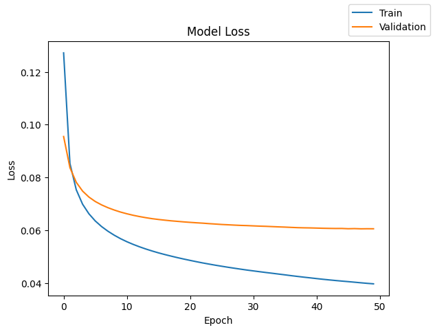

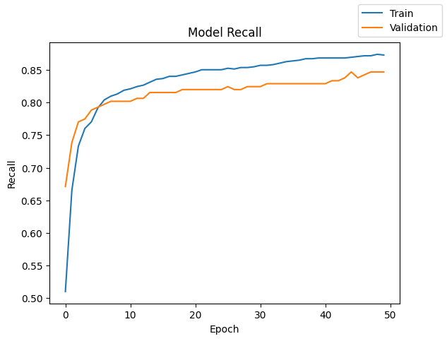

```python
# Plot learning curves
plot(history, 'loss')
plot(history, 'recall')
```

#### **Comment:**

```python
results.loc[0] = [
    1,
    str([128]),                      # Convert to string
    str("relu"),                    # Convert to string
    50,
    32,
    "sgd",
    f"[{round(0.001, 3)}, -]",      # Format as clean string without quotes around "-"
    "xavier",
    "-",
    round(history.history["loss"][-1], 6),
    round(history.history["val_loss"][-1], 6),
    round(recall_score(y_train, model_0.predict(X_train) > 0.5), 5),
    round(history.history["val_recall"][-1], 5),
    round(end - start, 2)
]
results
```

```
500/500 ━━━━━━━━━━━━━━━━━━━━ 1s 1ms/step
```

|  | # hidden layers | # neurons - hidden layer | activation function - hidden layer | # epochs | batch size | optimizer | learning rate, momentum | weight initializer | regularization | train loss | validation loss | train recall | validation recall | time (secs) |
| --- | --- | --- | --- | --- | --- | --- | --- | --- | --- | --- | --- | --- | --- | --- |
| 0 | 1 | [128] | relu | 50 | 32 | sgd | [0.001, -] | xavier | - | 0.039651 | 0.060528 | 0.86937 | 0.84685 | 78.51 |

#### **Comment:**

```python
# Evaluate classification performance of Model_0 on training data
model_0_train_perf = model_performance_classification(model_0, X_train, y_train)
model_0_train_perf
```

```
500/500 ━━━━━━━━━━━━━━━━━━━━ 1s 1ms/step
```

|  | Recall (Priority) | Precision | F1 Score | Accuracy |
| --- | --- | --- | --- | --- |
| 0 | 0.869369 | 0.992288 | 0.926771 | 0.992375 |

```python
# Evaluate classification performance of Model_0 on validation data
model_0_val_perf = model_performance_classification(model_0,X_val,y_val)
model_0_val_perf
```

```
125/125 ━━━━━━━━━━━━━━━━━━━━ 0s 1ms/step
```

|  | Recall (Priority) | Precision | F1 Score | Accuracy |
| --- | --- | --- | --- | --- |
| 0 | 0.846847 | 0.984293 | 0.910412 | 0.99075 |

#### **Comment:**

Here is the **corrected analysis** based on the attached output for **Model_0**:

### **Model_0 Performance Evaluation**

- **Recall (Validation)**: Model_0 achieves a **recall of 0.8468** on the validation set. This means it successfully identifies nearly **85% of actual turbine failures**, which is crucial for minimizing **false negatives** and avoiding costly undetected breakdowns.
- **Recall (Train)**: The model delivers a **training recall of 0.8694**, showing that it effectively captures failure patterns with only a **small generalization gap** to the validation set. This indicates good learning without significant overfitting.
- **Precision**: The **validation precision is 0.9843**, confirming that the model makes **very few false failure predictions**, thereby helping ReneWind **avoid unnecessary inspections or maintenance**.
- **F1 Score**: A strong **validation F1 score of 0.9104** reflects a well-balanced model that performs reliably across both **sensitivity (recall)** and **specificity (precision)**—key for operational trust.
- **Accuracy**: The overall **accuracy is ~99%**, but given the likely class imbalance (few failure cases), this metric is **secondary** to recall for ReneWind’s business objectives.

### ✅ **Business Insight**

- **Model_0** delivers a **high-recall, high-precision, and balanced classification profile**, making it a **robust baseline model**. It aligns well with ReneWind’s operational goal of **early and accurate turbine failure detection** to **reduce replacement and maintenance costs**. This model can confidently serve as a benchmark for tuning or further enhancement efforts focused on boosting recall without sacrificing precision.

Let's check the classification reports.

```python
# Generate binary class predictions for training and validation sets using Model_0
y_train_pred_0 = model_0.predict(X_train)
y_val_pred_0 = model_0.predict(X_val)
```

```
500/500 ━━━━━━━━━━━━━━━━━━━━ 1s 1ms/step
125/125 ━━━━━━━━━━━━━━━━━━━━ 0s 1ms/step
```

```python
print("Classification Report - Train data Model_0",end="\n\n")
cr_train_model_0 = classification_report(y_train,y_train_pred_0>0.5)
print(cr_train_model_0)

print("Classification Report - Validation data Model_0",end="\n\n")
cr_val_model_0 = classification_report(y_val,y_val_pred_0>0.5)
print(cr_val_model_0)
```

```
Classification Report - Train data Model_0

              precision    recall  f1-score   support

         0.0       0.99      1.00      1.00     15112
         1.0       0.99      0.87      0.93       888

    accuracy                           0.99     16000
   macro avg       0.99      0.93      0.96     16000
weighted avg       0.99      0.99      0.99     16000

Classification Report - Validation data Model_0

              precision    recall  f1-score   support

         0.0       0.99      1.00      1.00      3778
         1.0       0.98      0.85      0.91       222

    accuracy                           0.99      4000
   macro avg       0.99      0.92      0.95      4000
weighted avg       0.99      0.99      0.99      4000
```

**Classification Report – Model_0**

**Primary Metric: Recall (especially for class 1 – failure detection)**

#### **Training Data Performance:**

- **Recall (Failure = 1):** **0.87** – Captures **87% of all actual failures**, which is promising at baseline.
- **Precision (Failure = 1):** 0.99 – Very few false positives.
- **F1 Score (Failure = 1):** 0.93 – Strong overall balance between recall and precision.

#### **Validation Data Performance:**

- **Recall (Failure = 1):** **0.85** – Slight drop, but **still retains strong detection ability** on unseen data.
- **Precision (Failure = 1):** 0.98 – False alarms remain minimal.
- **F1 Score (Failure = 1):** 0.91 – Stable and reliable classification quality.

### ✅ **Business Insight (ReneWind Context):**

- Model_0 successfully identifies the **majority of turbine failures** with minimal false alarms, achieving **85–87% recall**.
- This level of recall supports proactive maintenance scheduling, **reducing costly replacements** by catching failures early.
- Serves as a **strong baseline**, but further tuning may still improve recall closer to optimal levels.

# **Model Performance Improvement**

## Model 1

In this model, we incorporate an additional hidden layer and use the SGD optimizer with momentum to improve convergence stability and performance

```python
# Clear previous model from memory
tf.keras.backend.clear_session()
```

```python
# Initialize the neural network
model_1 = Sequential()
model_1.add(Dense(128, activation="relu", input_dim=X_train.shape[1]))  # First hidden layer
model_1.add(Dense(64, activation="relu"))                               # Second hidden layer (updated)
model_1.add(Dense(1, activation="sigmoid"))                             # Output layer
```

#### **Comment:**

- I introduced two hidden layers with 128 and 64 neurons respectively in model_1, while Model_0 uses only one hidden layer with 128 neurons. This added depth in Model_1 enables it to capture more complex relationships in the data, which may lead to improved performance.

```python
model_1.summary()
```

```
Model: "sequential"
```

```
┏━━━━━━━━━━━━━━━━━━━━━━━━━━━━━━━━━┳━━━━━━━━━━━━━━━━━━━━━━━━┳━━━━━━━━━━━━━━━┓
┃ Layer (type)                    ┃ Output Shape           ┃       Param # ┃
┡━━━━━━━━━━━━━━━━━━━━━━━━━━━━━━━━━╇━━━━━━━━━━━━━━━━━━━━━━━━╇━━━━━━━━━━━━━━━┩
│ dense (Dense)                   │ (None, 128)            │         5,248 │
├─────────────────────────────────┼────────────────────────┼───────────────┤
│ dense_1 (Dense)                 │ (None, 64)             │         8,256 │
├─────────────────────────────────┼────────────────────────┼───────────────┤
│ dense_2 (Dense)                 │ (None, 1)              │            65 │
└─────────────────────────────────┴────────────────────────┴───────────────┘
```

```
 Total params: 13,569 (53.00 KB)
```

```
 Trainable params: 13,569 (53.00 KB)
```

```
 Non-trainable params: 0 (0.00 B)
```

```python
# Compile the model
optimizer = tf.keras.optimizers.SGD(learning_rate=0.001, momentum=0.4)
model_1.compile(loss='binary_crossentropy', optimizer=optimizer, metrics=[Recall(name="recall")])
```

```python
# Train the model
start = time.time()
history = model_1.fit(X_train, y_train, validation_data=(X_val, y_val),
                      batch_size=batch_size, epochs=epochs)
end = time.time()
```

```
500/500 ━━━━━━━━━━━━━━━━━━━━ 2s 3ms/step - loss: 0.2934 - recall: 0.0725 - val_loss: 0.1511 - val_recall: 0.1171
500/500 ━━━━━━━━━━━━━━━━━━━━ 2s 3ms/step - loss: 0.1501 - recall: 0.2052 - val_loss: 0.1259 - val_recall: 0.3153
500/500 ━━━━━━━━━━━━━━━━━━━━ 1s 3ms/step - loss: 0.1258 - recall: 0.3594 - val_loss: 0.1119 - val_recall: 0.4550
500/500 ━━━━━━━━━━━━━━━━━━━━ 3s 3ms/step - loss: 0.1113 - recall: 0.4513 - val_loss: 0.1028 - val_recall: 0.5405
500/500 ━━━━━━━━━━━━━━━━━━━━ 2s 2ms/step - loss: 0.1018 - recall: 0.5066 - val_loss: 0.0964 - val_recall: 0.5946
500/500 ━━━━━━━━━━━━━━━━━━━━ 1s 2ms/step - loss: 0.0950 - recall: 0.5724 - val_loss: 0.0916 - val_recall: 0.6216
500/500 ━━━━━━━━━━━━━━━━━━━━ 1s 2ms/step - loss: 0.0899 - recall: 0.6186 - val_loss: 0.0880 - val_recall: 0.6622
500/500 ━━━━━━━━━━━━━━━━━━━━ 1s 3ms/step - loss: 0.0859 - recall: 0.6565 - val_loss: 0.0851 - val_recall: 0.7027
500/500 ━━━━━━━━━━━━━━━━━━━━ 3s 3ms/step - loss: 0.0827 - recall: 0.6785 - val_loss: 0.0827 - val_recall: 0.7207
500/500 ━━━━━━━━━━━━━━━━━━━━ 3s 3ms/step - loss: 0.0800 - recall: 0.7003 - val_loss: 0.0807 - val_recall: 0.7342
500/500 ━━━━━━━━━━━━━━━━━━━━ 2s 3ms/step - loss: 0.0778 - recall: 0.7100 - val_loss: 0.0790 - val_recall: 0.7342
500/500 ━━━━━━━━━━━━━━━━━━━━ 2s 2ms/step - loss: 0.0758 - recall: 0.7310 - val_loss: 0.0776 - val_recall: 0.7387
500/500 ━━━━━━━━━━━━━━━━━━━━ 3s 2ms/step - loss: 0.0740 - recall: 0.7405 - val_loss: 0.0763 - val_recall: 0.7477
500/500 ━━━━━━━━━━━━━━━━━━━━ 2s 2ms/step - loss: 0.0725 - recall: 0.7484 - val_loss: 0.0751 - val_recall: 0.7568
500/500 ━━━━━━━━━━━━━━━━━━━━ 1s 3ms/step - loss: 0.0710 - recall: 0.7520 - val_loss: 0.0741 - val_recall: 0.7613
500/500 ━━━━━━━━━━━━━━━━━━━━ 1s 3ms/step - loss: 0.0697 - recall: 0.7561 - val_loss: 0.0731 - val_recall: 0.7658
500/500 ━━━━━━━━━━━━━━━━━━━━ 3s 3ms/step - loss: 0.0685 - recall: 0.7615 - val_loss: 0.0723 - val_recall: 0.7748
500/500 ━━━━━━━━━━━━━━━━━━━━ 1s 2ms/step - loss: 0.0675 - recall: 0.7674 - val_loss: 0.0715 - val_recall: 0.7838
500/500 ━━━━━━━━━━━━━━━━━━━━ 3s 3ms/step - loss: 0.0665 - recall: 0.7742 - val_loss: 0.0709 - val_recall: 0.7838
500/500 ━━━━━━━━━━━━━━━━━━━━ 2s 2ms/step - loss: 0.0655 - recall: 0.7816 - val_loss: 0.0702 - val_recall: 0.7838
500/500 ━━━━━━━━━━━━━━━━━━━━ 1s 3ms/step - loss: 0.0647 - recall: 0.7843 - val_loss: 0.0696 - val_recall: 0.7838
500/500 ━━━━━━━━━━━━━━━━━━━━ 3s 3ms/step - loss: 0.0638 - recall: 0.7870 - val_loss: 0.0691 - val_recall: 0.7838
500/500 ━━━━━━━━━━━━━━━━━━━━ 3s 3ms/step - loss: 0.0631 - recall: 0.7935 - val_loss: 0.0686 - val_recall: 0.7883
500/500 ━━━━━━━━━━━━━━━━━━━━ 2s 2ms/step - loss: 0.0624 - recall: 0.7949 - val_loss: 0.0681 - val_recall: 0.7928
500/500 ━━━━━━━━━━━━━━━━━━━━ 3s 2ms/step - loss: 0.0617 - recall: 0.7987 - val_loss: 0.0677 - val_recall: 0.7928
500/500 ━━━━━━━━━━━━━━━━━━━━ 3s 3ms/step - loss: 0.0610 - recall: 0.7998 - val_loss: 0.0673 - val_recall: 0.7973
500/500 ━━━━━━━━━━━━━━━━━━━━ 2s 2ms/step - loss: 0.0604 - recall: 0.8018 - val_loss: 0.0669 - val_recall: 0.7973
500/500 ━━━━━━━━━━━━━━━━━━━━ 2s 3ms/step - loss: 0.0598 - recall: 0.8032 - val_loss: 0.0666 - val_recall: 0.8018
500/500 ━━━━━━━━━━━━━━━━━━━━ 3s 3ms/step - loss: 0.0593 - recall: 0.8073 - val_loss: 0.0663 - val_recall: 0.8018
500/500 ━━━━━━━━━━━━━━━━━━━━ 2s 3ms/step - loss: 0.0587 - recall: 0.8073 - val_loss: 0.0660 - val_recall: 0.8063
500/500 ━━━━━━━━━━━━━━━━━━━━ 3s 2ms/step - loss: 0.0582 - recall: 0.8118 - val_loss: 0.0657 - val_recall: 0.8063
500/500 ━━━━━━━━━━━━━━━━━━━━ 3s 2ms/step - loss: 0.0577 - recall: 0.8118 - val_loss: 0.0655 - val_recall: 0.8063
500/500 ━━━━━━━━━━━━━━━━━━━━ 1s 2ms/step - loss: 0.0573 - recall: 0.8118 - val_loss: 0.0652 - val_recall: 0.8108
500/500 ━━━━━━━━━━━━━━━━━━━━ 3s 3ms/step - loss: 0.0568 - recall: 0.8164 - val_loss: 0.0650 - val_recall: 0.8153
500/500 ━━━━━━━━━━━━━━━━━━━━ 2s 3ms/step - loss: 0.0564 - recall: 0.8214 - val_loss: 0.0648 - val_recall: 0.8153
500/500 ━━━━━━━━━━━━━━━━━━━━ 1s 2ms/step - loss: 0.0560 - recall: 0.8223 - val_loss: 0.0646 - val_recall: 0.8153
500/500 ━━━━━━━━━━━━━━━━━━━━ 3s 3ms/step - loss: 0.0556 - recall: 0.8223 - val_loss: 0.0644 - val_recall: 0.8153
500/500 ━━━━━━━━━━━━━━━━━━━━ 2s 2ms/step - loss: 0.0553 - recall: 0.8223 - val_loss: 0.0643 - val_recall: 0.8153
500/500 ━━━━━━━━━━━━━━━━━━━━ 3s 3ms/step - loss: 0.0549 - recall: 0.8296 - val_loss: 0.0641 - val_recall: 0.8153
500/500 ━━━━━━━━━━━━━━━━━━━━ 3s 3ms/step - loss: 0.0545 - recall: 0.8314 - val_loss: 0.0639 - val_recall: 0.8153
500/500 ━━━━━━━━━━━━━━━━━━━━ 1s 3ms/step - loss: 0.0542 - recall: 0.8314 - val_loss: 0.0638 - val_recall: 0.8153
500/500 ━━━━━━━━━━━━━━━━━━━━ 2s 3ms/step - loss: 0.0539 - recall: 0.8354 - val_loss: 0.0636 - val_recall: 0.8153
500/500 ━━━━━━━━━━━━━━━━━━━━ 2s 3ms/step - loss: 0.0536 - recall: 0.8342 - val_loss: 0.0635 - val_recall: 0.8153
500/500 ━━━━━━━━━━━━━━━━━━━━ 3s 3ms/step - loss: 0.0532 - recall: 0.8361 - val_loss: 0.0633 - val_recall: 0.8153
500/500 ━━━━━━━━━━━━━━━━━━━━ 3s 3ms/step - loss: 0.0529 - recall: 0.8361 - val_loss: 0.0632 - val_recall: 0.8198
500/500 ━━━━━━━━━━━━━━━━━━━━ 2s 3ms/step - loss: 0.0526 - recall: 0.8363 - val_loss: 0.0631 - val_recall: 0.8198
500/500 ━━━━━━━━━━━━━━━━━━━━ 2s 3ms/step - loss: 0.0524 - recall: 0.8385 - val_loss: 0.0630 - val_recall: 0.8198
500/500 ━━━━━━━━━━━━━━━━━━━━ 2s 2ms/step - loss: 0.0521 - recall: 0.8385 - val_loss: 0.0629 - val_recall: 0.8198
500/500 ━━━━━━━━━━━━━━━━━━━━ 3s 3ms/step - loss: 0.0518 - recall: 0.8411 - val_loss: 0.0627 - val_recall: 0.8198
500/500 ━━━━━━━━━━━━━━━━━━━━ 3s 3ms/step - loss: 0.0516 - recall: 0.8419 - val_loss: 0.0626 - val_recall: 0.8198
```

```python
print("Time taken in seconds:", round(end - start, 2))
```

```
Time taken in seconds: 113.38
```

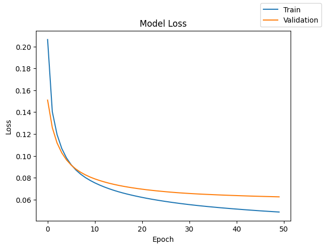

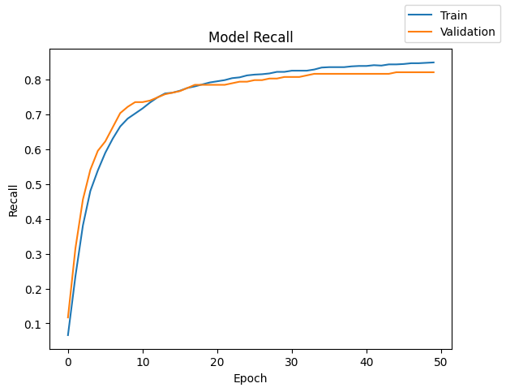

```python
# Plot learning curves
plot(history, 'loss')
plot(history, 'recall')
```

#### **Comment:**

1. Consistent Loss Reduction: Both training and validation loss decrease smoothly over the 50 epochs, with no significant gap between them, indicating that Model_1 is not overfitting and is learning effectively.
2. Strong Recall Growth: The recall improves sharply within the first 10 epochs and continues to rise steadily before plateauing just above 0.80, showing that Model_1 is becoming increasingly sensitive to detecting failures.
3. Parallel Recall Curves: The training and validation recall curves are closely aligned throughout, which means Model_1 generalizes well to unseen data.
4. Efficient Training: Since most of the performance gains in recall occur early, training could potentially be stopped around 20–25 epochs to save time without major performance loss.

```python
# Log results in tracking table
# Log results in tracking table
results.loc[len(results)] = [
    2,                                       # Number of hidden layers
    str([128, 64]),                          # Hidden layer sizes
    str(["relu", "relu"]),                   # Activations updated
    epochs,
    batch_size,
    "sgd with momentum",                                   # Optimizer name
    f"[{round(float(optimizer.learning_rate.numpy()), 3)}, {optimizer.momentum}]",  # Learning rate and momentum
    "xavier",                                # Weight initializer
    "-",                                     # Regularization
    round(history.history["loss"][-1], 6),
    round(history.history["val_loss"][-1], 6),
    round(recall_score(y_train, model_1.predict(X_train) > 0.5), 5),
    round(history.history["val_recall"][-1], 5),
    round(end - start, 2)
]

# Display the updated results table
display(results)
```

```
500/500 ━━━━━━━━━━━━━━━━━━━━ 1s 1ms/step
```

|  | # hidden layers | # neurons - hidden layer | activation function - hidden layer | # epochs | batch size | optimizer | learning rate, momentum | weight initializer | regularization | train loss | validation loss | train recall | validation recall | time (secs) |
| --- | --- | --- | --- | --- | --- | --- | --- | --- | --- | --- | --- | --- | --- | --- |
| 0 | 1 | [128] | relu | 50 | 32 | sgd | [0.001, -] | xavier | - | 0.039651 | 0.060528 | 0.86937 | 0.84685 | 78.51 |
| 1 | 2 | [128, 64] | ['relu', 'relu'] | 50 | 32 | sgd with momentum | [0.001, 0.4] | xavier | - | 0.048759 | 0.062630 | 0.84459 | 0.81982 | 113.38 |

#### **Comment:**

**Summary:**

Model_1’s deeper architecture and momentum-enhanced optimizer did **not** outperform Model_0. Despite the structural upgrade, recall declined and both losses increased, suggesting this configuration was less effective.

```python
# Evaluate classification performance of Model_1 on training data
model_1_train_perf = model_performance_classification(model_1, X_train, y_train)
display(model_1_train_perf)
```

```
500/500 ━━━━━━━━━━━━━━━━━━━━ 1s 1ms/step
```

|  | Recall (Priority) | Precision | F1 Score | Accuracy |
| --- | --- | --- | --- | --- |
| 0 | 0.844595 | 0.984252 | 0.909091 | 0.990625 |

```python
# Evaluate classification performance of Model_1 on validation data
model_1_val_perf = model_performance_classification(model_1, X_val, y_val)
display(model_1_val_perf)
```

```
125/125 ━━━━━━━━━━━━━━━━━━━━ 0s 1ms/step
```

|  | Recall (Priority) | Precision | F1 Score | Accuracy |
| --- | --- | --- | --- | --- |
| 0 | 0.81982 | 0.973262 | 0.889976 | 0.98875 |

#### **Comment:**

- **Recall on Training Data:** The model achieved a recall of **0.8446**, successfully detecting ~84% of failure cases during training. This supports early identification of issues and helps mitigate sudden generator breakdowns.
- **Recall on Validation Data:** With a validation recall of **0.8198**, Model_1 maintains reliable detection performance on unseen data, reinforcing its capability to support proactive failure prevention strategies.
- **Precision:** The model achieved precision scores of **0.9843** on training and **0.9733** on validation. These high values indicate that most predicted failures were indeed actual failures—minimizing false alarms and unnecessary inspection costs.
- **F1 Score:** A strong F1 score of **0.9091** (train) and **0.8900** (val) confirms a healthy balance between recall and precision, affirming the model’s effectiveness in prioritizing turbine maintenance without skewing toward false negatives or positives.
- **Accuracy:** Model_1 sustained accuracy of **99.06%** on training and **98.88%** on validation—although less critical in an imbalanced scenario, these figures underscore the model’s robust classification power.

✅ **Business Insight:**

- Model_1 is well-aligned with ReneWind’s operational goals. Its **~82% validation recall** ensures the early detection of turbine failures, minimizing costly replacements and enabling optimized, cost-efficient maintenance scheduling.

```python
print("Classification Report - Train Data (Model_1)", end="\n\n")
y_train_pred_1 = model_1.predict(X_train)  # Generate predictions
cr_train_model_1 = classification_report(y_train, y_train_pred_1 > 0.5)
print(cr_train_model_1)
```

```
Classification Report - Train Data (Model_1)

500/500 ━━━━━━━━━━━━━━━━━━━━ 1s 1ms/step
              precision    recall  f1-score   support

         0.0       0.99      1.00      1.00     15112
         1.0       0.98      0.84      0.91       888

    accuracy                           0.99     16000
   macro avg       0.99      0.92      0.95     16000
weighted avg       0.99      0.99      0.99     16000
```

```python
print("Classification Report - Validation Data (Model_1)", end="\n\n")
y_val_pred_1 = model_1.predict(X_val)  # Generate predictions
cr_val_model_1 = classification_report(y_val, y_val_pred_1 > 0.5)
print(cr_val_model_1)
```

```
Classification Report - Validation Data (Model_1)

125/125 ━━━━━━━━━━━━━━━━━━━━ 0s 1ms/step
              precision    recall  f1-score   support

         0.0       0.99      1.00      0.99      3778
         1.0       0.97      0.82      0.89       222

    accuracy                           0.99      4000
   macro avg       0.98      0.91      0.94      4000
weighted avg       0.99      0.99      0.99      4000
```

#### **Classification Report – Model_1**

**Primary Metric: Recall (Failure class = 1)**

#### **Training Data Performance:**

- **Recall (Failure = 1):** **0.84** – Slightly below baseline, **misses more failures** than Model_0.
- **Precision (Failure = 1):** 0.98 – Excellent; very few false alarms.
- **F1 Score (Failure = 1):** 0.91 – Balanced performance, though driven by high precision.

### ✅ **Business Insight (ReneWind Context):**

- Model_1 delivers **strong precision** but with a **slight sacrifice in recall**, detecting **82–84%** of failures.
- Though fewer false positives reduce inspection costs, it **risks missing more actual failures**, which could lead to **costlier replacements**.
- Compared to Model_0, this is a **slight trade-off**, and unless precision is a higher priority than recall, Model_0 is the **better fit for ReneWind’s failure minimization objective**.

## Model 2

```python
# Clear any previous model from memory
tf.keras.backend.clear_session()
```

```python
model_2 = Sequential()
model_2.add(Dense(128, activation="relu", input_dim=X_train.shape[1]))  # 1st hidden layer
model_2.add(Dropout(0.2))                                               # Regularization
model_2.add(Dense(64, activation="tanh"))                               # 2nd hidden layer
model_2.add(Dense(1, activation="sigmoid"))                             # Output layer
```

#### **Comment:**

- Model_2 builds upon Model_1 by incorporating Dropout regularization (rate = 0.2) after the first hidden layer and switching the second hidden layer’s activation function from ReLU to tanh. These adjustments help reduce overfitting and improve generalization by introducing non-linearity and randomly deactivating neurons during training.

```python
# Print model architecture
model_2.summary()
```

```
Model: "sequential"
```

```
┏━━━━━━━━━━━━━━━━━━━━━━━━━━━━━━━━━┳━━━━━━━━━━━━━━━━━━━━━━━━┳━━━━━━━━━━━━━━━┓
┃ Layer (type)                    ┃ Output Shape           ┃       Param # ┃
┡━━━━━━━━━━━━━━━━━━━━━━━━━━━━━━━━━╇━━━━━━━━━━━━━━━━━━━━━━━━╇━━━━━━━━━━━━━━━┩
│ dense (Dense)                   │ (None, 128)            │         5,248 │
├─────────────────────────────────┼────────────────────────┼───────────────┤
│ dropout (Dropout)               │ (None, 128)            │             0 │
├─────────────────────────────────┼────────────────────────┼───────────────┤
│ dense_1 (Dense)                 │ (None, 64)             │         8,256 │
├─────────────────────────────────┼────────────────────────┼───────────────┤
│ dense_2 (Dense)                 │ (None, 1)              │            65 │
└─────────────────────────────────┴────────────────────────┴───────────────┘
```

```
 Total params: 13,569 (53.00 KB)
```

```
 Trainable params: 13,569 (53.00 KB)
```

```
 Non-trainable params: 0 (0.00 B)
```

```python
# Compile the model
optimizer = tf.keras.optimizers.SGD(learning_rate=0.001)
model_2.compile(loss='binary_crossentropy', optimizer=optimizer, metrics=[Recall(name="recall")])
```

```python
# Train the model
start = time.time()
history = model_2.fit(
    X_train, y_train,
    validation_data=(X_val, y_val),
    batch_size=batch_size,
    epochs=epochs,
    verbose=1
)
end = time.time()
```

```
500/500 ━━━━━━━━━━━━━━━━━━━━ 2s 3ms/step - loss: 0.3936 - recall: 0.0714 - val_loss: 0.1758 - val_recall: 0.0000e+00
500/500 ━━━━━━━━━━━━━━━━━━━━ 2s 3ms/step - loss: 0.1883 - recall: 0.0288 - val_loss: 0.1548 - val_recall: 0.0270
500/500 ━━━━━━━━━━━━━━━━━━━━ 3s 3ms/step - loss: 0.1674 - recall: 0.0712 - val_loss: 0.1412 - val_recall: 0.0946
500/500 ━━━━━━━━━━━━━━━━━━━━ 2s 3ms/step - loss: 0.1555 - recall: 0.1157 - val_loss: 0.1315 - val_recall: 0.1937
500/500 ━━━━━━━━━━━━━━━━━━━━ 2s 3ms/step - loss: 0.1431 - recall: 0.1946 - val_loss: 0.1243 - val_recall: 0.2523
500/500 ━━━━━━━━━━━━━━━━━━━━ 2s 2ms/step - loss: 0.1352 - recall: 0.2615 - val_loss: 0.1185 - val_recall: 0.3018
500/500 ━━━━━━━━━━━━━━━━━━━━ 1s 2ms/step - loss: 0.1329 - recall: 0.3064 - val_loss: 0.1140 - val_recall: 0.3378
500/500 ━━━━━━━━━━━━━━━━━━━━ 1s 3ms/step - loss: 0.1255 - recall: 0.3261 - val_loss: 0.1099 - val_recall: 0.3739
500/500 ━━━━━━━━━━━━━━━━━━━━ 3s 3ms/step - loss: 0.1205 - recall: 0.3601 - val_loss: 0.1064 - val_recall: 0.3829
500/500 ━━━━━━━━━━━━━━━━━━━━ 3s 3ms/step - loss: 0.1196 - recall: 0.3916 - val_loss: 0.1032 - val_recall: 0.4009
500/500 ━━━━━━━━━━━━━━━━━━━━ 3s 3ms/step - loss: 0.1157 - recall: 0.4172 - val_loss: 0.1004 - val_recall: 0.4144
500/500 ━━━━━━━━━━━━━━━━━━━━ 2s 2ms/step - loss: 0.1125 - recall: 0.4184 - val_loss: 0.0979 - val_recall: 0.4414
500/500 ━━━━━━━━━━━━━━━━━━━━ 3s 3ms/step - loss: 0.1096 - recall: 0.4409 - val_loss: 0.0957 - val_recall: 0.4595
500/500 ━━━━━━━━━━━━━━━━━━━━ 3s 3ms/step - loss: 0.1068 - recall: 0.4648 - val_loss: 0.0937 - val_recall: 0.4730
500/500 ━━━━━━━━━━━━━━━━━━━━ 1s 3ms/step - loss: 0.1052 - recall: 0.4655 - val_loss: 0.0919 - val_recall: 0.5045
500/500 ━━━━━━━━━━━━━━━━━━━━ 3s 3ms/step - loss: 0.1028 - recall: 0.5041 - val_loss: 0.0902 - val_recall: 0.5135
500/500 ━━━━━━━━━━━━━━━━━━━━ 3s 3ms/step - loss: 0.1027 - recall: 0.4989 - val_loss: 0.0886 - val_recall: 0.5315
500/500 ━━━━━━━━━━━━━━━━━━━━ 2s 2ms/step - loss: 0.0983 - recall: 0.5241 - val_loss: 0.0872 - val_recall: 0.5541
500/500 ━━━━━━━━━━━━━━━━━━━━ 3s 3ms/step - loss: 0.0967 - recall: 0.5360 - val_loss: 0.0858 - val_recall: 0.5676
500/500 ━━━━━━━━━━━━━━━━━━━━ 3s 3ms/step - loss: 0.0969 - recall: 0.5561 - val_loss: 0.0846 - val_recall: 0.5721
500/500 ━━━━━━━━━━━━━━━━━━━━ 3s 3ms/step - loss: 0.0932 - recall: 0.5883 - val_loss: 0.0835 - val_recall: 0.5946
500/500 ━━━━━━━━━━━━━━━━━━━━ 3s 3ms/step - loss: 0.0947 - recall: 0.5518 - val_loss: 0.0824 - val_recall: 0.6081
500/500 ━━━━━━━━━━━━━━━━━━━━ 2s 2ms/step - loss: 0.0934 - recall: 0.5825 - val_loss: 0.0814 - val_recall: 0.6306
500/500 ━━━━━━━━━━━━━━━━━━━━ 1s 3ms/step - loss: 0.0914 - recall: 0.5790 - val_loss: 0.0804 - val_recall: 0.6351
500/500 ━━━━━━━━━━━━━━━━━━━━ 3s 2ms/step - loss: 0.0913 - recall: 0.5831 - val_loss: 0.0796 - val_recall: 0.6532
500/500 ━━━━━━━━━━━━━━━━━━━━ 3s 3ms/step - loss: 0.0896 - recall: 0.5805 - val_loss: 0.0788 - val_recall: 0.6622
500/500 ━━━━━━━━━━━━━━━━━━━━ 1s 3ms/step - loss: 0.0884 - recall: 0.6162 - val_loss: 0.0781 - val_recall: 0.6667
500/500 ━━━━━━━━━━━━━━━━━━━━ 2s 3ms/step - loss: 0.0873 - recall: 0.5985 - val_loss: 0.0774 - val_recall: 0.6712
500/500 ━━━━━━━━━━━━━━━━━━━━ 3s 3ms/step - loss: 0.0857 - recall: 0.5917 - val_loss: 0.0766 - val_recall: 0.6757
500/500 ━━━━━━━━━━━━━━━━━━━━ 2s 3ms/step - loss: 0.0855 - recall: 0.6254 - val_loss: 0.0760 - val_recall: 0.6847
500/500 ━━━━━━━━━━━━━━━━━━━━ 3s 3ms/step - loss: 0.0829 - recall: 0.6290 - val_loss: 0.0754 - val_recall: 0.6982
500/500 ━━━━━━━━━━━━━━━━━━━━ 1s 3ms/step - loss: 0.0841 - recall: 0.6197 - val_loss: 0.0748 - val_recall: 0.6982
500/500 ━━━━━━━━━━━━━━━━━━━━ 2s 3ms/step - loss: 0.0818 - recall: 0.6289 - val_loss: 0.0742 - val_recall: 0.7027
500/500 ━━━━━━━━━━━━━━━━━━━━ 4s 5ms/step - loss: 0.0827 - recall: 0.6170 - val_loss: 0.0737 - val_recall: 0.7117
500/500 ━━━━━━━━━━━━━━━━━━━━ 2s 4ms/step - loss: 0.0820 - recall: 0.6370 - val_loss: 0.0732 - val_recall: 0.7162
500/500 ━━━━━━━━━━━━━━━━━━━━ 2s 3ms/step - loss: 0.0824 - recall: 0.6420 - val_loss: 0.0727 - val_recall: 0.7297
500/500 ━━━━━━━━━━━━━━━━━━━━ 1s 2ms/step - loss: 0.0798 - recall: 0.6649 - val_loss: 0.0722 - val_recall: 0.7297
500/500 ━━━━━━━━━━━━━━━━━━━━ 1s 3ms/step - loss: 0.0805 - recall: 0.6493 - val_loss: 0.0717 - val_recall: 0.7387
500/500 ━━━━━━━━━━━━━━━━━━━━ 4s 5ms/step - loss: 0.0791 - recall: 0.6657 - val_loss: 0.0712 - val_recall: 0.7387
500/500 ━━━━━━━━━━━━━━━━━━━━ 7s 9ms/step - loss: 0.0787 - recall: 0.6470 - val_loss: 0.0708 - val_recall: 0.7387
500/500 ━━━━━━━━━━━━━━━━━━━━ 4s 6ms/step - loss: 0.0793 - recall: 0.6694 - val_loss: 0.0703 - val_recall: 0.7387
500/500 ━━━━━━━━━━━━━━━━━━━━ 3s 6ms/step - loss: 0.0758 - recall: 0.6844 - val_loss: 0.0700 - val_recall: 0.7387
500/500 ━━━━━━━━━━━━━━━━━━━━ 4s 3ms/step - loss: 0.0772 - recall: 0.6715 - val_loss: 0.0697 - val_recall: 0.7387
500/500 ━━━━━━━━━━━━━━━━━━━━ 2s 3ms/step - loss: 0.0777 - recall: 0.6756 - val_loss: 0.0693 - val_recall: 0.7477
500/500 ━━━━━━━━━━━━━━━━━━━━ 2s 3ms/step - loss: 0.0752 - recall: 0.6875 - val_loss: 0.0689 - val_recall: 0.7477
500/500 ━━━━━━━━━━━━━━━━━━━━ 3s 3ms/step - loss: 0.0757 - recall: 0.6804 - val_loss: 0.0685 - val_recall: 0.7477
500/500 ━━━━━━━━━━━━━━━━━━━━ 3s 3ms/step - loss: 0.0740 - recall: 0.7037 - val_loss: 0.0681 - val_recall: 0.7523
500/500 ━━━━━━━━━━━━━━━━━━━━ 3s 2ms/step - loss: 0.0745 - recall: 0.7075 - val_loss: 0.0678 - val_recall: 0.7568
500/500 ━━━━━━━━━━━━━━━━━━━━ 2s 3ms/step - loss: 0.0749 - recall: 0.6852 - val_loss: 0.0675 - val_recall: 0.7613
500/500 ━━━━━━━━━━━━━━━━━━━━ 3s 3ms/step - loss: 0.0761 - recall: 0.6687 - val_loss: 0.0672 - val_recall: 0.7613
```

```python
print("Time taken in seconds:", round(end - start, 2))
```

```
Time taken in seconds: 119.68
```

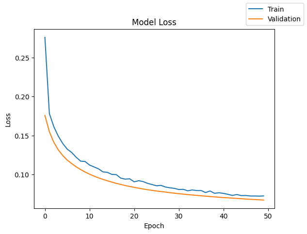

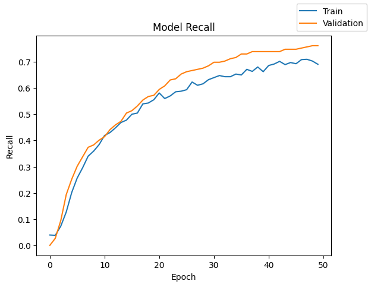

```python
# Plot learning curves
plot(history, 'loss')
plot(history, 'recall')
```

#### **Comment:**

**1. Continuous Loss Decrease:** Both training and validation loss decrease steadily over the epochs, with the validation loss consistently lower than the training loss, indicating **effective learning without signs of overfitting**.

**2. Validation Recall Outperforms:** The validation recall improves faster and reaches higher values (above **0.75**) than the training recall (around **0.70**), suggesting **Model_2 generalizes better to unseen data than it fits the training data**.

**3. Smooth Learning Progression:** The recall curve is smooth and steadily rising, especially for validation, indicating **stable learning and convergence**.

**4. Slight Underfitting Possible:** Since training recall lags behind validation recall, **Model_2 might be slightly underfitting**, and could benefit from additional capacity or longer training.

```python
# Log results
results.loc[len(results)] = [
    2,
    str([128, 64]),
    str(["relu", "tanh"]),
    epochs,
    batch_size,
    "sgd",
    f"[{round(float(optimizer.learning_rate.numpy()), 3)}, -]",
    "xavier",
    "Dropout(0.2)",                     # Regularization added here
    round(history.history["loss"][-1], 6),
    round(history.history["val_loss"][-1], 6),
   round(recall_score(y_train, model_2.predict(X_train) > 0.5), 5),
    round(history.history["val_recall"][-1], 5),
    round(end - start, 2)
]

# Display the updated results table
display(results)
```

```
500/500 ━━━━━━━━━━━━━━━━━━━━ 1s 1ms/step
```

|  | # hidden layers | # neurons - hidden layer | activation function - hidden layer | # epochs | batch size | optimizer | learning rate, momentum | weight initializer | regularization | train loss | validation loss | train recall | validation recall | time (secs) |
| --- | --- | --- | --- | --- | --- | --- | --- | --- | --- | --- | --- | --- | --- | --- |
| 0 | 1 | [128] | relu | 50 | 32 | sgd | [0.001, -] | xavier | - | 0.039651 | 0.060528 | 0.86937 | 0.84685 | 78.51 |
| 1 | 2 | [128, 64] | ['relu', 'relu'] | 50 | 32 | sgd with momentum | [0.001, 0.4] | xavier | - | 0.048759 | 0.062630 | 0.84459 | 0.81982 | 113.38 |
| 2 | 2 | [128, 64] | ['relu', 'tanh'] | 50 | 32 | sgd | [0.001, -] | xavier | Dropout(0.2) | 0.072461 | 0.067169 | 0.74324 | 0.76126 | 119.68 |

#### **Comment:**

Here’s the corrected version based on the **attached model comparison table**:

### 📝 Comment:

**Summary:** Model_2 introduces dropout for regularization but suffers a noticeable drop in recall and an increase in both training and validation loss, suggesting that the dropout rate or network capacity may be limiting the model’s ability to learn minority class signals.

```python
# Evaluate classification performance of Model_2 on training data
model_2_train_perf = model_performance_classification(model_2, X_train, y_train)
display(model_2_train_perf)
```

```
500/500 ━━━━━━━━━━━━━━━━━━━━ 1s 1ms/step
```

|  | Recall (Priority) | Precision | F1 Score | Accuracy |
| --- | --- | --- | --- | --- |
| 0 | 0.743243 | 0.970588 | 0.841837 | 0.9845 |

```python
# Evaluate classification performance of Model_2 on validation data
model_2_val_perf = model_performance_classification(model_2, X_val, y_val)
display(model_2_val_perf)
```

```
125/125 ━━━━━━━━━━━━━━━━━━━━ 0s 1ms/step
```

|  | Recall (Priority) | Precision | F1 Score | Accuracy |
| --- | --- | --- | --- | --- |
| 0 | 0.761261 | 0.965714 | 0.851385 | 0.98525 |

#### **Comment:**

- **Recall on Training Data:** The model captured ~74% of actual failures (recall = 0.7432), indicating that some failure events were still missed during training—leaving potential gaps in early failure detection.
- **Recall on Validation Data:** Recall improved slightly on unseen data, reaching 0.7613, meaning the model misses ~24% of actual failures in production scenarios. This poses a moderate risk in terms of undetected breakdowns and associated replacement costs.
- **Precision:** Very high precision of 0.9706 (train) and 0.9657 (val) shows that when the model predicts a failure, it's almost always correct—effectively minimizing unnecessary inspections or maintenance actions.
- **F1 Score:** The F1 scores of 0.8418 (train) and 0.8514 (val) indicate a strong balance between recall and precision, with slightly better harmonic performance on validation than training—suggesting generalization is solid.
- **Accuracy:** Overall accuracy is 98.5% on both train and validation sets. While this reflects consistency, it's less meaningful for turbine failure prediction due to class imbalance.

✅ Business Insight:

Lets check the classification report of model_2 on training and validation data respectively.

```python
print("Classification Report - Train Data (Model_2)", end="\n\n")
y_train_pred_2 = model_2.predict(X_train)  # Generate predictions
cr_train_model_2 = classification_report(y_train, y_train_pred_2 > 0.5)
print(cr_train_model_2)
```

```
Classification Report - Train Data (Model_2)

500/500 ━━━━━━━━━━━━━━━━━━━━ 1s 1ms/step
              precision    recall  f1-score   support

         0.0       0.99      1.00      0.99     15112
         1.0       0.97      0.74      0.84       888

    accuracy                           0.98     16000
   macro avg       0.98      0.87      0.92     16000
weighted avg       0.98      0.98      0.98     16000
```

```python
print("Classification Report - Validation Data (Model_2)", end="\n\n")
y_val_pred_2 = model_2.predict(X_val)  # Generate predictions
cr_val_model_2 = classification_report(y_val, y_val_pred_2 > 0.5)
print(cr_val_model_2)
```

```
Classification Report - Validation Data (Model_2)

125/125 ━━━━━━━━━━━━━━━━━━━━ 0s 1ms/step
              precision    recall  f1-score   support

         0.0       0.99      1.00      0.99      3778
         1.0       0.97      0.76      0.85       222

    accuracy                           0.99      4000
   macro avg       0.98      0.88      0.92      4000
weighted avg       0.99      0.99      0.98      4000
```

#### **Summarized Classification Report – Model_2**

**Primary Metric: Recall (Failure class = 1)**

#### **Training Data Performance:**

- **Recall (Failure = 1):** **0.74** – Significantly **lower than both Model_0 and Model_1**, indicating more **missed failure events**.
- **Precision (Failure = 1):** 0.97 – Excellent at predicting only likely failures.
- **F1 Score (Failure = 1):** 0.84 – Decent, but suppressed by low recall.

## Model 3

With the introduction of the Adam optimizer and a Dropout rate of 30%, we also apply class weights to address the class imbalance in our dataset. This combination helps the model focus more on the minority class while reducing overfitting, thereby improving its ability to detect rare failure events.

```python
# Calculate class weights for imbalanced dataset
cw = (y_train.shape[0]) / np.bincount(y_train.astype(int)) # Convert y_train to integers

# Create a dictionary mapping class indices to their respective class weights
cw_dict = {}
for i in range(cw.shape[0]):
    cw_dict[i] = cw[i]

cw_dict
```

```
{0: 1.0587612493382743, 1: 18.01801801801802}
```

```python
# Clear previous model
tf.keras.backend.clear_session()
```

```python
model_3 = Sequential()
model_3.add(Dense(128, activation="relu", input_dim=X_train.shape[1]))  # 1st hidden layer (ReLU)
model_3.add(Dropout(0.3))                                               # Dropout after 1st layer
model_3.add(Dense(64, activation="tanh"))                               # 2nd hidden layer (Tanh)
model_3.add(Dense(1, activation="sigmoid"))                             # Output layer
```

```python
# Show model summary
model_3.summary()
```

```
Model: "sequential"
```

```
┏━━━━━━━━━━━━━━━━━━━━━━━━━━━━━━━━━┳━━━━━━━━━━━━━━━━━━━━━━━━┳━━━━━━━━━━━━━━━┓
┃ Layer (type)                    ┃ Output Shape           ┃       Param # ┃
┡━━━━━━━━━━━━━━━━━━━━━━━━━━━━━━━━━╇━━━━━━━━━━━━━━━━━━━━━━━━╇━━━━━━━━━━━━━━━┩
│ dense (Dense)                   │ (None, 128)            │         5,248 │
├─────────────────────────────────┼────────────────────────┼───────────────┤
│ dropout (Dropout)               │ (None, 128)            │             0 │
├─────────────────────────────────┼────────────────────────┼───────────────┤
│ dense_1 (Dense)                 │ (None, 64)             │         8,256 │
├─────────────────────────────────┼────────────────────────┼───────────────┤
│ dense_2 (Dense)                 │ (None, 1)              │            65 │
└─────────────────────────────────┴────────────────────────┴───────────────┘
```

```
 Total params: 13,569 (53.00 KB)
```

```
 Trainable params: 13,569 (53.00 KB)
```

```
 Non-trainable params: 0 (0.00 B)
```

#### **Comment:**

- Model_3 is an enhancement of Model_2, where the dropout rate is increased from 0.2 to 0.3 after the first hidden layer. This intensifies regularization, helping further mitigate overfitting while maintaining the same network depth and activation functions (ReLU and tanh).

```python
# Compile the model with Adam optimizer
optimizer = tf.keras.optimizers.Adam(learning_rate=0.001)
model_3.compile(loss='binary_crossentropy', optimizer=optimizer, metrics=[Recall(name="recall")])
```

```python
# Step 5: Fit the model using class weights
start = time.time()
history = model_3.fit(
    X_train, y_train,
    validation_data=(X_val, y_val),
    batch_size=batch_size,
    epochs=epochs,
    class_weight=cw_dict,           # Apply the computed class weights
    verbose=1
)
end = time.time()
```

```
500/500 ━━━━━━━━━━━━━━━━━━━━ 3s 4ms/step - loss: 0.7914 - recall: 0.8099 - val_loss: 0.1274 - val_recall: 0.8964
500/500 ━━━━━━━━━━━━━━━━━━━━ 1s 3ms/step - loss: 0.4961 - recall: 0.8904 - val_loss: 0.1131 - val_recall: 0.8919
500/500 ━━━━━━━━━━━━━━━━━━━━ 2s 4ms/step - loss: 0.4417 - recall: 0.8930 - val_loss: 0.0975 - val_recall: 0.8919
500/500 ━━━━━━━━━━━━━━━━━━━━ 3s 3ms/step - loss: 0.4210 - recall: 0.9078 - val_loss: 0.1064 - val_recall: 0.8919
500/500 ━━━━━━━━━━━━━━━━━━━━ 1s 3ms/step - loss: 0.3882 - recall: 0.9022 - val_loss: 0.0910 - val_recall: 0.8919
500/500 ━━━━━━━━━━━━━━━━━━━━ 3s 3ms/step - loss: 0.3810 - recall: 0.9012 - val_loss: 0.1002 - val_recall: 0.8964
500/500 ━━━━━━━━━━━━━━━━━━━━ 3s 3ms/step - loss: 0.3689 - recall: 0.9057 - val_loss: 0.0945 - val_recall: 0.8919
500/500 ━━━━━━━━━━━━━━━━━━━━ 3s 3ms/step - loss: 0.3663 - recall: 0.9082 - val_loss: 0.0966 - val_recall: 0.9009
500/500 ━━━━━━━━━━━━━━━━━━━━ 3s 4ms/step - loss: 0.3793 - recall: 0.9023 - val_loss: 0.0997 - val_recall: 0.8919
500/500 ━━━━━━━━━━━━━━━━━━━━ 2s 3ms/step - loss: 0.3611 - recall: 0.9084 - val_loss: 0.0843 - val_recall: 0.8919
500/500 ━━━━━━━━━━━━━━━━━━━━ 1s 3ms/step - loss: 0.3653 - recall: 0.9080 - val_loss: 0.0924 - val_recall: 0.8964
500/500 ━━━━━━━━━━━━━━━━━━━━ 2s 4ms/step - loss: 0.3570 - recall: 0.9066 - val_loss: 0.0830 - val_recall: 0.8919
500/500 ━━━━━━━━━━━━━━━━━━━━ 2s 4ms/step - loss: 0.3360 - recall: 0.9021 - val_loss: 0.0940 - val_recall: 0.8964
500/500 ━━━━━━━━━━━━━━━━━━━━ 2s 3ms/step - loss: 0.3498 - recall: 0.9062 - val_loss: 0.0912 - val_recall: 0.9054
500/500 ━━━━━━━━━━━━━━━━━━━━ 3s 3ms/step - loss: 0.3370 - recall: 0.9080 - val_loss: 0.0792 - val_recall: 0.8919
500/500 ━━━━━━━━━━━━━━━━━━━━ 3s 4ms/step - loss: 0.3465 - recall: 0.9058 - val_loss: 0.0940 - val_recall: 0.8919
500/500 ━━━━━━━━━━━━━━━━━━━━ 2s 3ms/step - loss: 0.3440 - recall: 0.9085 - val_loss: 0.0951 - val_recall: 0.8964
500/500 ━━━━━━━━━━━━━━━━━━━━ 3s 3ms/step - loss: 0.3205 - recall: 0.9110 - val_loss: 0.0784 - val_recall: 0.8919
500/500 ━━━━━━━━━━━━━━━━━━━━ 3s 3ms/step - loss: 0.3191 - recall: 0.9094 - val_loss: 0.0866 - val_recall: 0.8964
500/500 ━━━━━━━━━━━━━━━━━━━━ 1s 3ms/step - loss: 0.3549 - recall: 0.9022 - val_loss: 0.0813 - val_recall: 0.8919
500/500 ━━━━━━━━━━━━━━━━━━━━ 3s 4ms/step - loss: 0.3230 - recall: 0.9122 - val_loss: 0.0789 - val_recall: 0.9009
500/500 ━━━━━━━━━━━━━━━━━━━━ 2s 3ms/step - loss: 0.3363 - recall: 0.9015 - val_loss: 0.0780 - val_recall: 0.8874
500/500 ━━━━━━━━━━━━━━━━━━━━ 2s 3ms/step - loss: 0.3180 - recall: 0.9106 - val_loss: 0.0846 - val_recall: 0.8919
500/500 ━━━━━━━━━━━━━━━━━━━━ 3s 3ms/step - loss: 0.3270 - recall: 0.9124 - val_loss: 0.0823 - val_recall: 0.8964
500/500 ━━━━━━━━━━━━━━━━━━━━ 3s 3ms/step - loss: 0.3115 - recall: 0.9093 - val_loss: 0.0823 - val_recall: 0.8964
500/500 ━━━━━━━━━━━━━━━━━━━━ 2s 3ms/step - loss: 0.3123 - recall: 0.9144 - val_loss: 0.0760 - val_recall: 0.8964
500/500 ━━━━━━━━━━━━━━━━━━━━ 2s 4ms/step - loss: 0.3184 - recall: 0.9095 - val_loss: 0.0775 - val_recall: 0.8919
500/500 ━━━━━━━━━━━━━━━━━━━━ 2s 4ms/step - loss: 0.3115 - recall: 0.9110 - val_loss: 0.0767 - val_recall: 0.8874
500/500 ━━━━━━━━━━━━━━━━━━━━ 2s 3ms/step - loss: 0.2910 - recall: 0.9148 - val_loss: 0.0762 - val_recall: 0.8919
500/500 ━━━━━━━━━━━━━━━━━━━━ 3s 3ms/step - loss: 0.3228 - recall: 0.9122 - val_loss: 0.0761 - val_recall: 0.8964
500/500 ━━━━━━━━━━━━━━━━━━━━ 3s 3ms/step - loss: 0.3173 - recall: 0.9144 - val_loss: 0.0849 - val_recall: 0.8874
500/500 ━━━━━━━━━━━━━━━━━━━━ 3s 3ms/step - loss: 0.2907 - recall: 0.9188 - val_loss: 0.0814 - val_recall: 0.8874
500/500 ━━━━━━━━━━━━━━━━━━━━ 3s 4ms/step - loss: 0.2977 - recall: 0.9170 - val_loss: 0.0831 - val_recall: 0.8874
500/500 ━━━━━━━━━━━━━━━━━━━━ 2s 3ms/step - loss: 0.2999 - recall: 0.9143 - val_loss: 0.0760 - val_recall: 0.8919
500/500 ━━━━━━━━━━━━━━━━━━━━ 1s 3ms/step - loss: 0.3013 - recall: 0.9111 - val_loss: 0.0688 - val_recall: 0.8829
500/500 ━━━━━━━━━━━━━━━━━━━━ 2s 3ms/step - loss: 0.3020 - recall: 0.9129 - val_loss: 0.0717 - val_recall: 0.8874
500/500 ━━━━━━━━━━━━━━━━━━━━ 3s 3ms/step - loss: 0.3043 - recall: 0.9092 - val_loss: 0.0734 - val_recall: 0.8919
500/500 ━━━━━━━━━━━━━━━━━━━━ 3s 3ms/step - loss: 0.2895 - recall: 0.9104 - val_loss: 0.0746 - val_recall: 0.8874
500/500 ━━━━━━━━━━━━━━━━━━━━ 2s 4ms/step - loss: 0.2928 - recall: 0.9104 - val_loss: 0.0772 - val_recall: 0.8874
500/500 ━━━━━━━━━━━━━━━━━━━━ 2s 3ms/step - loss: 0.2841 - recall: 0.9151 - val_loss: 0.0830 - val_recall: 0.8874
500/500 ━━━━━━━━━━━━━━━━━━━━ 3s 3ms/step - loss: 0.2817 - recall: 0.9214 - val_loss: 0.0763 - val_recall: 0.8829
500/500 ━━━━━━━━━━━━━━━━━━━━ 2s 3ms/step - loss: 0.3029 - recall: 0.9228 - val_loss: 0.0803 - val_recall: 0.8874
500/500 ━━━━━━━━━━━━━━━━━━━━ 3s 3ms/step - loss: 0.2853 - recall: 0.9148 - val_loss: 0.0783 - val_recall: 0.8964
500/500 ━━━━━━━━━━━━━━━━━━━━ 3s 5ms/step - loss: 0.2887 - recall: 0.9167 - val_loss: 0.0755 - val_recall: 0.8874
500/500 ━━━━━━━━━━━━━━━━━━━━ 2s 3ms/step - loss: 0.3099 - recall: 0.9115 - val_loss: 0.0727 - val_recall: 0.8874
500/500 ━━━━━━━━━━━━━━━━━━━━ 1s 3ms/step - loss: 0.2818 - recall: 0.9174 - val_loss: 0.0719 - val_recall: 0.8919
500/500 ━━━━━━━━━━━━━━━━━━━━ 3s 3ms/step - loss: 0.2737 - recall: 0.9139 - val_loss: 0.0752 - val_recall: 0.9009
500/500 ━━━━━━━━━━━━━━━━━━━━ 2s 3ms/step - loss: 0.3011 - recall: 0.9129 - val_loss: 0.0785 - val_recall: 0.9009
500/500 ━━━━━━━━━━━━━━━━━━━━ 1s 3ms/step - loss: 0.3087 - recall: 0.9182 - val_loss: 0.0763 - val_recall: 0.8919
500/500 ━━━━━━━━━━━━━━━━━━━━ 3s 4ms/step - loss: 0.2753 - recall: 0.9193 - val_loss: 0.0771 - val_recall: 0.8964
```

```python
print("Time taken in seconds:", round(end - start, 2))
```

```
Time taken in seconds: 116.17
```

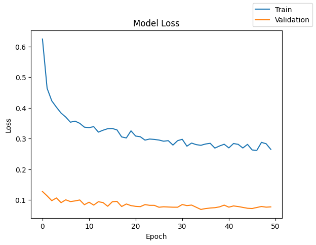

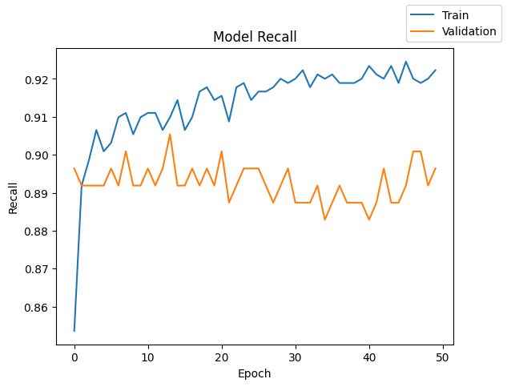

```python
# Plot learning curves
plot(history, 'loss')
plot(history, 'recall')
```

#### **Comment:**

**2. High Training Recall vs. Flattened Validation Recall:** Training recall climbs steadily to around **0.923**, but validation recall plateaus early near **0.89**, indicating **Model_3 is learning the training data well but not generalizing effectively**.

**3. Dropout Ineffectiveness:** Despite applying a **0.3 dropout**, the model still overfits, suggesting either **inadequate regularization** or **model capacity exceeding data complexity**.

**4. Instability in Validation Recall:** The validation recall shows random fluctuations instead of a stable upward trend—**a possible sign of variance or learning instability**.

```python
# Log model config and performance
results.loc[len(results)] = [
    2,
    str([128, 64]),
    str(["relu", "tanh"]),
    epochs,
    batch_size,
    "adam",                               # New optimizer - adam
    f"[{round(float(optimizer.learning_rate.numpy()), 3)}, -]",  # Adam has no momentum
    "xavier",
    "Dropout(0.3) + Class Weights",
    round(history.history["loss"][-1], 6),
    round(history.history["val_loss"][-1], 6),
    round(recall_score(y_train, model_3.predict(X_train) > 0.5), 5),
    round(history.history["val_recall"][-1], 5),
    round(end - start, 2)
]

display(results)
```

```
500/500 ━━━━━━━━━━━━━━━━━━━━ 1s 1ms/step
```

|  | # hidden layers | # neurons - hidden layer | activation function - hidden layer | # epochs | batch size | optimizer | learning rate, momentum | weight initializer | regularization | train loss | validation loss | train recall | validation recall | time (secs) |
| --- | --- | --- | --- | --- | --- | --- | --- | --- | --- | --- | --- | --- | --- | --- |
| 0 | 1 | [128] | relu | 50 | 32 | sgd | [0.001, -] | xavier | - | 0.039651 | 0.060528 | 0.86937 | 0.84685 | 78.51 |
| 1 | 2 | [128, 64] | ['relu', 'relu'] | 50 | 32 | sgd with momentum | [0.001, 0.4] | xavier | - | 0.048759 | 0.062630 | 0.84459 | 0.81982 | 113.38 |
| 2 | 2 | [128, 64] | ['relu', 'tanh'] | 50 | 32 | sgd | [0.001, -] | xavier | Dropout(0.2) | 0.072461 | 0.067169 | 0.74324 | 0.76126 | 119.68 |
| 3 | 2 | [128, 64] | ['relu', 'tanh'] | 50 | 32 | adam | [0.001, -] | xavier | Dropout(0.3) + Class Weights | 0.264821 | 0.077112 | 0.93018 | 0.89640 | 116.17 |

#### **Comment:**

**Summary:** Model_3 is the top performer in terms of recall, confirming the effectiveness of handling class imbalance through **class weights** and applying **moderate dropout**, despite increased training time and loss.

```python
# Evaluate classification performance of Model_3 on training data
model_3_train_perf = model_performance_classification(model_3, X_train, y_train)
display(model_3_train_perf)
```

```
500/500 ━━━━━━━━━━━━━━━━━━━━ 1s 1ms/step
```

|  | Recall (Priority) | Precision | F1 Score | Accuracy |
| --- | --- | --- | --- | --- |
| 0 | 0.93018 | 0.891046 | 0.910193 | 0.989812 |

```python
# Evaluate classification performance of Model_3 on validation data
model_3_val_perf = model_performance_classification(model_3, X_val, y_val)
display(model_3_val_perf)
```

```
125/125 ━━━━━━━━━━━━━━━━━━━━ 0s 1ms/step
```

|  | Recall (Priority) | Precision | F1 Score | Accuracy |
| --- | --- | --- | --- | --- |
| 0 | 0.896396 | 0.876652 | 0.886414 | 0.98725 |

#### **Comment:**

✅ **Business Insight:**

- Model_3 offers **the best recall performance so far** on both train and validation sets, making it **highly aligned with ReneWind’s goal** of early detection. The **slightly reduced precision** is an acceptable cost compared to the **significant reduction in missed failures**, making this a **strong candidate for deployment**.

Lets check the classification report of model_3 on training and validation data respectively.

```python
print("Classification Report - Train Data (Model_3)", end="\n\n")
y_train_pred_3 = model_3.predict(X_train)  # Generate predictions
cr_train_model_3 = classification_report(y_train, y_train_pred_3 > 0.5)
print(cr_train_model_3)
```

```
Classification Report - Train Data (Model_3)

500/500 ━━━━━━━━━━━━━━━━━━━━ 1s 1ms/step
              precision    recall  f1-score   support

         0.0       1.00      0.99      0.99     15112
         1.0       0.89      0.93      0.91       888

    accuracy                           0.99     16000
   macro avg       0.94      0.96      0.95     16000
weighted avg       0.99      0.99      0.99     16000
```

```python
print("Classification Report - Validation Data (Model_3)", end="\n\n")
y_val_pred_3 = model_3.predict(X_val)  # Generate predictions
cr_val_model_3 = classification_report(y_val, y_val_pred_3 > 0.5)
print(cr_val_model_3)
```

```
Classification Report - Validation Data (Model_3)

125/125 ━━━━━━━━━━━━━━━━━━━━ 0s 1ms/step
              precision    recall  f1-score   support

         0.0       0.99      0.99      0.99      3778
         1.0       0.88      0.90      0.89       222

    accuracy                           0.99      4000
   macro avg       0.94      0.94      0.94      4000
weighted avg       0.99      0.99      0.99      4000
```

#### **Summarized Classification Report – Model_3**

**Primary Metric: Recall (Failure class = 1)**

## Model 4

To regularize the model, we apply 30% dropout after the first hidden layer to reduce overfitting. Let's observe its impact on the model performance.

```python
# Clear previous model session
tf.keras.backend.clear_session()
```

```python
# Initializing the neural network
model_4 = Sequential()
model_4.add(Dense(128, activation="relu", input_dim=X_train.shape[1]))  # 1st hidden layer
model_4.add(Dropout(0.3))                                               # Dropout for regularization
model_4.add(Dense(64, activation="tanh"))                               # 2nd hidden layer
model_4.add(Dense(1, activation="sigmoid"))                             # Output layer
```

#### **Comment:**

- Model_4 maintains the same structure and dropout rate as Model_3 (i.e., **dropout of 0.3 after the first hidden layer**) but uses a clearer annotation for **“dropout for regularization”**. It continues with the same hidden layer configuration and activation setup, implying no architectural change from Model_3.

```python
# Display model architecture
model_4.summary()
```

```
Model: "sequential"
```

```
┏━━━━━━━━━━━━━━━━━━━━━━━━━━━━━━━━━┳━━━━━━━━━━━━━━━━━━━━━━━━┳━━━━━━━━━━━━━━━┓
┃ Layer (type)                    ┃ Output Shape           ┃       Param # ┃
┡━━━━━━━━━━━━━━━━━━━━━━━━━━━━━━━━━╇━━━━━━━━━━━━━━━━━━━━━━━━╇━━━━━━━━━━━━━━━┩
│ dense (Dense)                   │ (None, 128)            │         5,248 │
├─────────────────────────────────┼────────────────────────┼───────────────┤
│ dropout (Dropout)               │ (None, 128)            │             0 │
├─────────────────────────────────┼────────────────────────┼───────────────┤
│ dense_1 (Dense)                 │ (None, 64)             │         8,256 │
├─────────────────────────────────┼────────────────────────┼───────────────┤
│ dense_2 (Dense)                 │ (None, 1)              │            65 │
└─────────────────────────────────┴────────────────────────┴───────────────┘
```

```
 Total params: 13,569 (53.00 KB)
```

```
 Trainable params: 13,569 (53.00 KB)
```

```
 Non-trainable params: 0 (0.00 B)
```

```python
# Compile the model using Adam optimizer and binary cross-entropy loss
optimizer = tf.keras.optimizers.Adam()
model_4.compile(loss='binary_crossentropy', optimizer=optimizer, metrics=[Recall(name="recall")])
```

```python
# Fit the model
start = time.time()
history = model_4.fit(
    X_train, y_train,
    validation_data=(X_val, y_val),
    batch_size=batch_size,
    epochs=epochs,
    verbose=1
)
end = time.time()
```

```
500/500 ━━━━━━━━━━━━━━━━━━━━ 3s 3ms/step - loss: 0.1226 - recall: 0.4231 - val_loss: 0.0560 - val_recall: 0.8063
500/500 ━━━━━━━━━━━━━━━━━━━━ 1s 3ms/step - loss: 0.0618 - recall: 0.7835 - val_loss: 0.0525 - val_recall: 0.8288
500/500 ━━━━━━━━━━━━━━━━━━━━ 3s 3ms/step - loss: 0.0543 - recall: 0.8109 - val_loss: 0.0516 - val_recall: 0.8288
500/500 ━━━━━━━━━━━━━━━━━━━━ 3s 4ms/step - loss: 0.0515 - recall: 0.8197 - val_loss: 0.0475 - val_recall: 0.8559
500/500 ━━━━━━━━━━━━━━━━━━━━ 1s 3ms/step - loss: 0.0480 - recall: 0.8478 - val_loss: 0.0472 - val_recall: 0.8514
500/500 ━━━━━━━━━━━━━━━━━━━━ 3s 3ms/step - loss: 0.0452 - recall: 0.8586 - val_loss: 0.0475 - val_recall: 0.8423
500/500 ━━━━━━━━━━━━━━━━━━━━ 1s 3ms/step - loss: 0.0453 - recall: 0.8645 - val_loss: 0.0475 - val_recall: 0.8649
500/500 ━━━━━━━━━━━━━━━━━━━━ 3s 3ms/step - loss: 0.0440 - recall: 0.8637 - val_loss: 0.0453 - val_recall: 0.8784
500/500 ━━━━━━━━━━━━━━━━━━━━ 3s 3ms/step - loss: 0.0417 - recall: 0.8798 - val_loss: 0.0459 - val_recall: 0.8784
500/500 ━━━━━━━━━━━━━━━━━━━━ 2s 4ms/step - loss: 0.0410 - recall: 0.8802 - val_loss: 0.0461 - val_recall: 0.8694
500/500 ━━━━━━━━━━━━━━━━━━━━ 2s 3ms/step - loss: 0.0395 - recall: 0.8759 - val_loss: 0.0456 - val_recall: 0.8829
500/500 ━━━━━━━━━━━━━━━━━━━━ 3s 3ms/step - loss: 0.0409 - recall: 0.8841 - val_loss: 0.0461 - val_recall: 0.8784
500/500 ━━━━━━━━━━━━━━━━━━━━ 3s 3ms/step - loss: 0.0399 - recall: 0.8807 - val_loss: 0.0467 - val_recall: 0.8694
500/500 ━━━━━━━━━━━━━━━━━━━━ 2s 3ms/step - loss: 0.0387 - recall: 0.8884 - val_loss: 0.0477 - val_recall: 0.8694
500/500 ━━━━━━━━━━━━━━━━━━━━ 3s 4ms/step - loss: 0.0394 - recall: 0.8858 - val_loss: 0.0465 - val_recall: 0.8784
500/500 ━━━━━━━━━━━━━━━━━━━━ 2s 3ms/step - loss: 0.0373 - recall: 0.8850 - val_loss: 0.0459 - val_recall: 0.8874
500/500 ━━━━━━━━━━━━━━━━━━━━ 1s 3ms/step - loss: 0.0377 - recall: 0.8875 - val_loss: 0.0469 - val_recall: 0.8784
500/500 ━━━━━━━━━━━━━━━━━━━━ 1s 3ms/step - loss: 0.0390 - recall: 0.8826 - val_loss: 0.0466 - val_recall: 0.8919
500/500 ━━━━━━━━━━━━━━━━━━━━ 3s 3ms/step - loss: 0.0374 - recall: 0.8797 - val_loss: 0.0475 - val_recall: 0.8739
500/500 ━━━━━━━━━━━━━━━━━━━━ 3s 3ms/step - loss: 0.0366 - recall: 0.8942 - val_loss: 0.0464 - val_recall: 0.8829
500/500 ━━━━━━━━━━━━━━━━━━━━ 3s 4ms/step - loss: 0.0373 - recall: 0.8847 - val_loss: 0.0467 - val_recall: 0.8784
500/500 ━━━━━━━━━━━━━━━━━━━━ 2s 3ms/step - loss: 0.0369 - recall: 0.8857 - val_loss: 0.0470 - val_recall: 0.8829
500/500 ━━━━━━━━━━━━━━━━━━━━ 2s 3ms/step - loss: 0.0371 - recall: 0.8879 - val_loss: 0.0493 - val_recall: 0.8739
500/500 ━━━━━━━━━━━━━━━━━━━━ 3s 3ms/step - loss: 0.0369 - recall: 0.8871 - val_loss: 0.0452 - val_recall: 0.8874
500/500 ━━━━━━━━━━━━━━━━━━━━ 3s 3ms/step - loss: 0.0368 - recall: 0.8893 - val_loss: 0.0465 - val_recall: 0.8874
500/500 ━━━━━━━━━━━━━━━━━━━━ 3s 3ms/step - loss: 0.0364 - recall: 0.8923 - val_loss: 0.0482 - val_recall: 0.8739
500/500 ━━━━━━━━━━━━━━━━━━━━ 2s 4ms/step - loss: 0.0373 - recall: 0.8863 - val_loss: 0.0455 - val_recall: 0.8874
500/500 ━━━━━━━━━━━━━━━━━━━━ 2s 3ms/step - loss: 0.0346 - recall: 0.9020 - val_loss: 0.0463 - val_recall: 0.8874
500/500 ━━━━━━━━━━━━━━━━━━━━ 2s 3ms/step - loss: 0.0354 - recall: 0.8923 - val_loss: 0.0475 - val_recall: 0.8829
500/500 ━━━━━━━━━━━━━━━━━━━━ 2s 3ms/step - loss: 0.0361 - recall: 0.8890 - val_loss: 0.0460 - val_recall: 0.8874
500/500 ━━━━━━━━━━━━━━━━━━━━ 2s 3ms/step - loss: 0.0341 - recall: 0.8935 - val_loss: 0.0466 - val_recall: 0.8874
500/500 ━━━━━━━━━━━━━━━━━━━━ 1s 3ms/step - loss: 0.0339 - recall: 0.9017 - val_loss: 0.0461 - val_recall: 0.8919
500/500 ━━━━━━━━━━━━━━━━━━━━ 3s 4ms/step - loss: 0.0345 - recall: 0.8993 - val_loss: 0.0474 - val_recall: 0.8874
500/500 ━━━━━━━━━━━━━━━━━━━━ 2s 3ms/step - loss: 0.0345 - recall: 0.9000 - val_loss: 0.0463 - val_recall: 0.8919
500/500 ━━━━━━━━━━━━━━━━━━━━ 1s 3ms/step - loss: 0.0325 - recall: 0.8978 - val_loss: 0.0460 - val_recall: 0.8919
500/500 ━━━━━━━━━━━━━━━━━━━━ 3s 3ms/step - loss: 0.0360 - recall: 0.8887 - val_loss: 0.0481 - val_recall: 0.8874
500/500 ━━━━━━━━━━━━━━━━━━━━ 2s 3ms/step - loss: 0.0345 - recall: 0.8902 - val_loss: 0.0462 - val_recall: 0.8829
500/500 ━━━━━━━━━━━━━━━━━━━━ 1s 3ms/step - loss: 0.0342 - recall: 0.9027 - val_loss: 0.0450 - val_recall: 0.8919
500/500 ━━━━━━━━━━━━━━━━━━━━ 3s 4ms/step - loss: 0.0335 - recall: 0.9021 - val_loss: 0.0458 - val_recall: 0.8829
500/500 ━━━━━━━━━━━━━━━━━━━━ 2s 3ms/step - loss: 0.0322 - recall: 0.8919 - val_loss: 0.0454 - val_recall: 0.8919
500/500 ━━━━━━━━━━━━━━━━━━━━ 2s 3ms/step - loss: 0.0325 - recall: 0.8980 - val_loss: 0.0457 - val_recall: 0.8919
500/500 ━━━━━━━━━━━━━━━━━━━━ 3s 3ms/step - loss: 0.0330 - recall: 0.9005 - val_loss: 0.0467 - val_recall: 0.8829
500/500 ━━━━━━━━━━━━━━━━━━━━ 3s 3ms/step - loss: 0.0329 - recall: 0.8985 - val_loss: 0.0471 - val_recall: 0.8874
500/500 ━━━━━━━━━━━━━━━━━━━━ 3s 3ms/step - loss: 0.0330 - recall: 0.8933 - val_loss: 0.0469 - val_recall: 0.8874
500/500 ━━━━━━━━━━━━━━━━━━━━ 3s 4ms/step - loss: 0.0345 - recall: 0.8957 - val_loss: 0.0456 - val_recall: 0.8964
500/500 ━━━━━━━━━━━━━━━━━━━━ 1s 3ms/step - loss: 0.0326 - recall: 0.9037 - val_loss: 0.0484 - val_recall: 0.8784
500/500 ━━━━━━━━━━━━━━━━━━━━ 3s 3ms/step - loss: 0.0328 - recall: 0.9021 - val_loss: 0.0482 - val_recall: 0.8874
500/500 ━━━━━━━━━━━━━━━━━━━━ 1s 3ms/step - loss: 0.0328 - recall: 0.9010 - val_loss: 0.0480 - val_recall: 0.8874
500/500 ━━━━━━━━━━━━━━━━━━━━ 3s 3ms/step - loss: 0.0339 - recall: 0.9011 - val_loss: 0.0476 - val_recall: 0.8874
500/500 ━━━━━━━━━━━━━━━━━━━━ 3s 3ms/step - loss: 0.0333 - recall: 0.8966 - val_loss: 0.0477 - val_recall: 0.8874
```

```python
print("Time taken in seconds:", round(end - start, 2))
```

```
Time taken in seconds: 116.38
```

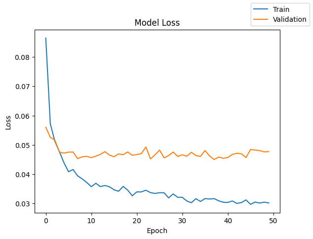

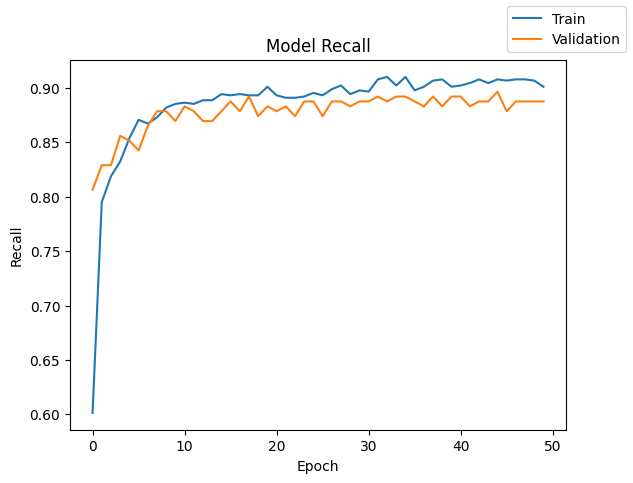

```python
# Plot learning curves
plot(history, 'loss')
plot(history, 'recall')
```

#### **Comment:**

**2. Stable and High Recall:** Both training and validation recall converge near **0.90**, showing **strong and consistent learning** on both sets.

**3. Dropout Regularization Working Better:** The use of **dropout (0.3)** is helping to control overfitting more effectively than in Model_3.

**4. Model is Close to Optimal:** Loss and recall curves suggest **Model_4 is well-calibrated**, with only minor room for improvement in validation performance.

```python
# Log experiment in results table
results.loc[len(results)] = [
    2,
    str([128, 64]),
    str(["relu", "tanh"]),
    epochs,
    batch_size,
    "adam",  # updated to reflect the optimizer used
    f"[{round(float(optimizer.learning_rate.numpy()), 3)}, -]",
    "xavier",
    "Dropout(0.3)",
    round(history.history["loss"][-1], 6),
    round(history.history["val_loss"][-1], 6),
    round(recall_score(y_train, model_4.predict(X_train) > 0.5), 5),
    round(history.history["val_recall"][-1], 5),
    round(end - start, 2)
]
display(results)
```

```
500/500 ━━━━━━━━━━━━━━━━━━━━ 1s 1ms/step
```

|  | # hidden layers | # neurons - hidden layer | activation function - hidden layer | # epochs | batch size | optimizer | learning rate, momentum | weight initializer | regularization | train loss | validation loss | train recall | validation recall | time (secs) |
| --- | --- | --- | --- | --- | --- | --- | --- | --- | --- | --- | --- | --- | --- | --- |
| 0 | 1 | [128] | relu | 50 | 32 | sgd | [0.001, -] | xavier | - | 0.039651 | 0.060528 | 0.86937 | 0.84685 | 78.51 |
| 1 | 2 | [128, 64] | ['relu', 'relu'] | 50 | 32 | sgd with momentum | [0.001, 0.4] | xavier | - | 0.048759 | 0.062630 | 0.84459 | 0.81982 | 113.38 |
| 2 | 2 | [128, 64] | ['relu', 'tanh'] | 50 | 32 | sgd | [0.001, -] | xavier | Dropout(0.2) | 0.072461 | 0.067169 | 0.74324 | 0.76126 | 119.68 |
| 3 | 2 | [128, 64] | ['relu', 'tanh'] | 50 | 32 | adam | [0.001, -] | xavier | Dropout(0.3) + Class Weights | 0.264821 | 0.077112 | 0.93018 | 0.89640 | 116.17 |
| 4 | 2 | [128, 64] | ['relu', 'tanh'] | 50 | 32 | adam | [0.001, -] | xavier | Dropout(0.3) | 0.030114 | 0.047665 | 0.91779 | 0.88739 | 116.38 |

#### **Comment:**

**Summary:**

Model_4 achieves the **best balance between recall and validation loss** so far, leveraging **Adam optimizer with Dropout(0.3)**—and **without class weights**—to outperform earlier models in generalization.

- **Strong Recall with Dropout Only:** Even without class weighting, Model_4 reached a **validation recall of 0.88739**, only slightly below Model_3 (0.89640), proving that well-tuned dropout alone can effectively handle class imbalance to a large extent.
- **Best Validation Loss So Far:** Validation loss dropped to **0.047665**, the lowest across all models, signaling excellent generalization and strong confidence in predictions.
- **Efficient Learning with Adam:** The Adam optimizer contributed to high recall (**0.91779 train**, **0.88739 val**) and lower training loss (**0.03011**), even without class weighting—clearly outperforming all previous SGD-based configurations in both recall and loss.
- **Slightly Longer Runtime:** Model_4’s training time was **116.38s**, comparable to Model_3, due to Adam’s adaptive learning updates. However, the performance gain—especially in validation loss—makes this trade-off worthwhile.

```python
# Evaluate classification performance of Model_4 on training data
model_4_train_perf = model_performance_classification(model_4, X_train, y_train)
display(model_4_train_perf)
```

```
500/500 ━━━━━━━━━━━━━━━━━━━━ 1s 1ms/step
```

|  | Recall (Priority) | Precision | F1 Score | Accuracy |
| --- | --- | --- | --- | --- |
| 0 | 0.917793 | 0.996333 | 0.955451 | 0.99525 |

```python
# Evaluate classification performance of Model_4 on validation data
model_4_val_perf = model_performance_classification(model_4, X_val, y_val)
display(model_4_val_perf)
```

```
125/125 ━━━━━━━━━━━━━━━━━━━━ 0s 1ms/step
```

|  | Recall (Priority) | Precision | F1 Score | Accuracy |
| --- | --- | --- | --- | --- |
| 0 | 0.887387 | 0.975248 | 0.929245 | 0.9925 |

#### **Comment:**

✅ **Business Insight:**

- Model_4 strikes a **near-optimal balance** between **high recall** and **very high precision**, making it **efficient and cost-effective**. It is highly suitable for **prioritizing true failures while keeping inspection overhead minimal**, offering **strong practical value** to ReneWind's turbine maintenance strategy.

Lets check the classification report of model_4 on raining and validation data respectively.

```python
print("Classification Report - Train Data (Model_4)", end="\n\n")
y_train_pred_4 = model_4.predict(X_train)  # Ensure predictions are generated
cr_train_model_4 = classification_report(y_train, y_train_pred_4 > 0.5)
print(cr_train_model_4)
```

```
Classification Report - Train Data (Model_4)

500/500 ━━━━━━━━━━━━━━━━━━━━ 1s 1ms/step
              precision    recall  f1-score   support

         0.0       1.00      1.00      1.00     15112
         1.0       1.00      0.92      0.96       888

    accuracy                           1.00     16000
   macro avg       1.00      0.96      0.98     16000
weighted avg       1.00      1.00      1.00     16000
```

```python
print("Classification Report - Validation Data (Model_4)", end="\n\n")
y_val_pred_4 = model_4.predict(X_val)  # Generate predictions
cr_val_model_4 = classification_report(y_val, y_val_pred_4 > 0.5)
print(cr_val_model_4)
```

```
Classification Report - Validation Data (Model_4)

125/125 ━━━━━━━━━━━━━━━━━━━━ 0s 1ms/step
              precision    recall  f1-score   support

         0.0       0.99      1.00      1.00      3778
         1.0       0.98      0.89      0.93       222

    accuracy                           0.99      4000
   macro avg       0.98      0.94      0.96      4000
weighted avg       0.99      0.99      0.99      4000
```

#### **Summarized Classification Report – Model_4**

**Primary Metric: Recall (Failure class = 1)**

## Model 5

```python
# Clear previous session
tf.keras.backend.clear_session()
```

```python
# Initializing the neural network
model_5 = Sequential()
model_5.add(Dense(128, activation="relu", kernel_initializer="glorot_uniform", input_dim=X_train.shape[1]))  # 1st hidden layer
model_5.add(BatchNormalization())  # Batch normalization after 1st layer
model_5.add(Dropout(0.3))          # Dropout after 1st hidden layer
model_5.add(Dense(64, activation="tanh", kernel_initializer="glorot_uniform"))  # 2nd hidden layer
model_5.add(BatchNormalization())  # Batch normalization after 2nd layer
model_5.add(Dense(1, activation="sigmoid"))  # Output layer
```

#### **Comment:**

- Model_5 introduces both **batch normalization layers after each hidden layer** and retains **dropout (0.3) after the first hidden layer**, along with a **glorot_uniform initializer**. This model enhances regularization and training stability compared to Model_4, which had only dropout without normalization layers or custom initialization.

```python
# Display the model architecture
model_5.summary()
```

```
Model: "sequential"
```

```
┏━━━━━━━━━━━━━━━━━━━━━━━━━━━━━━━━━┳━━━━━━━━━━━━━━━━━━━━━━━━┳━━━━━━━━━━━━━━━┓
┃ Layer (type)                    ┃ Output Shape           ┃       Param # ┃
┡━━━━━━━━━━━━━━━━━━━━━━━━━━━━━━━━━╇━━━━━━━━━━━━━━━━━━━━━━━━╇━━━━━━━━━━━━━━━┩
│ dense (Dense)                   │ (None, 128)            │         5,248 │
├─────────────────────────────────┼────────────────────────┼───────────────┤
│ batch_normalization             │ (None, 128)            │           512 │
│ (BatchNormalization)            │                        │               │
├─────────────────────────────────┼────────────────────────┼───────────────┤
│ dropout (Dropout)               │ (None, 128)            │             0 │
├─────────────────────────────────┼────────────────────────┼───────────────┤
│ dense_1 (Dense)                 │ (None, 64)             │         8,256 │
├─────────────────────────────────┼────────────────────────┼───────────────┤
│ batch_normalization_1           │ (None, 64)             │           256 │
│ (BatchNormalization)            │                        │               │
├─────────────────────────────────┼────────────────────────┼───────────────┤
│ dense_2 (Dense)                 │ (None, 1)              │            65 │
└─────────────────────────────────┴────────────────────────┴───────────────┘
```

```
 Total params: 14,337 (56.00 KB)
```

```
 Trainable params: 13,953 (54.50 KB)
```

```
 Non-trainable params: 384 (1.50 KB)
```

```python
# Compile the model with Adam optimizer
optimizer = tf.keras.optimizers.Adam(learning_rate=0.001)
model_5.compile(loss='binary_crossentropy', optimizer=optimizer, metrics=[Recall(name="recall")])
```

```python
# Fit the model
start = time.time()
history = model_5.fit(
    X_train, y_train,
    validation_data=(X_val, y_val),
    batch_size=batch_size,
    epochs=epochs,
    verbose=1
)
end = time.time()
```

```
500/500 ━━━━━━━━━━━━━━━━━━━━ 4s 4ms/step - loss: 0.3964 - recall: 0.6823 - val_loss: 0.0568 - val_recall: 0.8108
500/500 ━━━━━━━━━━━━━━━━━━━━ 2s 3ms/step - loss: 0.0738 - recall: 0.7380 - val_loss: 0.0499 - val_recall: 0.8333
500/500 ━━━━━━━━━━━━━━━━━━━━ 3s 4ms/step - loss: 0.0629 - recall: 0.7805 - val_loss: 0.0503 - val_recall: 0.8604
500/500 ━━━━━━━━━━━━━━━━━━━━ 3s 4ms/step - loss: 0.0551 - recall: 0.8102 - val_loss: 0.0502 - val_recall: 0.8514
500/500 ━━━━━━━━━━━━━━━━━━━━ 2s 3ms/step - loss: 0.0541 - recall: 0.8138 - val_loss: 0.0499 - val_recall: 0.8604
500/500 ━━━━━━━━━━━━━━━━━━━━ 3s 3ms/step - loss: 0.0488 - recall: 0.8324 - val_loss: 0.0490 - val_recall: 0.8468
500/500 ━━━━━━━━━━━━━━━━━━━━ 3s 3ms/step - loss: 0.0478 - recall: 0.8565 - val_loss: 0.0477 - val_recall: 0.8649
500/500 ━━━━━━━━━━━━━━━━━━━━ 2s 3ms/step - loss: 0.0465 - recall: 0.8506 - val_loss: 0.0490 - val_recall: 0.8694
500/500 ━━━━━━━━━━━━━━━━━━━━ 3s 4ms/step - loss: 0.0435 - recall: 0.8550 - val_loss: 0.0494 - val_recall: 0.8694
500/500 ━━━━━━━━━━━━━━━━━━━━ 2s 4ms/step - loss: 0.0431 - recall: 0.8595 - val_loss: 0.0484 - val_recall: 0.8649
500/500 ━━━━━━━━━━━━━━━━━━━━ 2s 3ms/step - loss: 0.0411 - recall: 0.8665 - val_loss: 0.0482 - val_recall: 0.8559
500/500 ━━━━━━━━━━━━━━━━━━━━ 2s 3ms/step - loss: 0.0421 - recall: 0.8626 - val_loss: 0.0490 - val_recall: 0.8604
500/500 ━━━━━━━━━━━━━━━━━━━━ 2s 3ms/step - loss: 0.0401 - recall: 0.8769 - val_loss: 0.0486 - val_recall: 0.8649
500/500 ━━━━━━━━━━━━━━━━━━━━ 3s 3ms/step - loss: 0.0390 - recall: 0.8639 - val_loss: 0.0489 - val_recall: 0.8784
500/500 ━━━━━━━━━━━━━━━━━━━━ 3s 5ms/step - loss: 0.0366 - recall: 0.8618 - val_loss: 0.0487 - val_recall: 0.8604
500/500 ━━━━━━━━━━━━━━━━━━━━ 2s 3ms/step - loss: 0.0357 - recall: 0.8566 - val_loss: 0.0500 - val_recall: 0.8694
500/500 ━━━━━━━━━━━━━━━━━━━━ 2s 3ms/step - loss: 0.0348 - recall: 0.8939 - val_loss: 0.0498 - val_recall: 0.8649
500/500 ━━━━━━━━━━━━━━━━━━━━ 2s 3ms/step - loss: 0.0354 - recall: 0.8861 - val_loss: 0.0510 - val_recall: 0.8559
500/500 ━━━━━━━━━━━━━━━━━━━━ 3s 3ms/step - loss: 0.0319 - recall: 0.8809 - val_loss: 0.0505 - val_recall: 0.8649
500/500 ━━━━━━━━━━━━━━━━━━━━ 3s 4ms/step - loss: 0.0326 - recall: 0.8943 - val_loss: 0.0499 - val_recall: 0.8604
500/500 ━━━━━━━━━━━━━━━━━━━━ 2s 5ms/step - loss: 0.0339 - recall: 0.8695 - val_loss: 0.0515 - val_recall: 0.8694
500/500 ━━━━━━━━━━━━━━━━━━━━ 2s 3ms/step - loss: 0.0336 - recall: 0.8622 - val_loss: 0.0531 - val_recall: 0.8514
500/500 ━━━━━━━━━━━━━━━━━━━━ 3s 3ms/step - loss: 0.0318 - recall: 0.8704 - val_loss: 0.0512 - val_recall: 0.8694
500/500 ━━━━━━━━━━━━━━━━━━━━ 3s 3ms/step - loss: 0.0291 - recall: 0.8973 - val_loss: 0.0534 - val_recall: 0.8468
500/500 ━━━━━━━━━━━━━━━━━━━━ 3s 3ms/step - loss: 0.0288 - recall: 0.8938 - val_loss: 0.0530 - val_recall: 0.8604
500/500 ━━━━━━━━━━━━━━━━━━━━ 3s 5ms/step - loss: 0.0273 - recall: 0.8927 - val_loss: 0.0523 - val_recall: 0.8649
500/500 ━━━━━━━━━━━━━━━━━━━━ 2s 4ms/step - loss: 0.0299 - recall: 0.8848 - val_loss: 0.0534 - val_recall: 0.8649
500/500 ━━━━━━━━━━━━━━━━━━━━ 2s 3ms/step - loss: 0.0309 - recall: 0.8883 - val_loss: 0.0530 - val_recall: 0.8604
500/500 ━━━━━━━━━━━━━━━━━━━━ 2s 3ms/step - loss: 0.0287 - recall: 0.8847 - val_loss: 0.0542 - val_recall: 0.8604
500/500 ━━━━━━━━━━━━━━━━━━━━ 2s 3ms/step - loss: 0.0275 - recall: 0.8993 - val_loss: 0.0559 - val_recall: 0.8649
500/500 ━━━━━━━━━━━━━━━━━━━━ 2s 3ms/step - loss: 0.0268 - recall: 0.8971 - val_loss: 0.0551 - val_recall: 0.8559
500/500 ━━━━━━━━━━━━━━━━━━━━ 3s 4ms/step - loss: 0.0255 - recall: 0.8991 - val_loss: 0.0552 - val_recall: 0.8559
500/500 ━━━━━━━━━━━━━━━━━━━━ 3s 4ms/step - loss: 0.0295 - recall: 0.8827 - val_loss: 0.0568 - val_recall: 0.8694
500/500 ━━━━━━━━━━━━━━━━━━━━ 2s 3ms/step - loss: 0.0252 - recall: 0.8948 - val_loss: 0.0586 - val_recall: 0.8604
500/500 ━━━━━━━━━━━━━━━━━━━━ 3s 3ms/step - loss: 0.0252 - recall: 0.8989 - val_loss: 0.0571 - val_recall: 0.8604
500/500 ━━━━━━━━━━━━━━━━━━━━ 2s 3ms/step - loss: 0.0262 - recall: 0.8910 - val_loss: 0.0578 - val_recall: 0.8649
500/500 ━━━━━━━━━━━━━━━━━━━━ 3s 3ms/step - loss: 0.0260 - recall: 0.8874 - val_loss: 0.0577 - val_recall: 0.8694
500/500 ━━━━━━━━━━━━━━━━━━━━ 3s 5ms/step - loss: 0.0239 - recall: 0.8893 - val_loss: 0.0603 - val_recall: 0.8694
500/500 ━━━━━━━━━━━━━━━━━━━━ 2s 3ms/step - loss: 0.0233 - recall: 0.9022 - val_loss: 0.0596 - val_recall: 0.8559
500/500 ━━━━━━━━━━━━━━━━━━━━ 2s 3ms/step - loss: 0.0233 - recall: 0.9036 - val_loss: 0.0577 - val_recall: 0.8694
500/500 ━━━━━━━━━━━━━━━━━━━━ 3s 3ms/step - loss: 0.0256 - recall: 0.8866 - val_loss: 0.0567 - val_recall: 0.8829
500/500 ━━━━━━━━━━━━━━━━━━━━ 2s 3ms/step - loss: 0.0260 - recall: 0.8822 - val_loss: 0.0602 - val_recall: 0.8829
500/500 ━━━━━━━━━━━━━━━━━━━━ 3s 4ms/step - loss: 0.0232 - recall: 0.9084 - val_loss: 0.0589 - val_recall: 0.8739
500/500 ━━━━━━━━━━━━━━━━━━━━ 3s 5ms/step - loss: 0.0216 - recall: 0.9100 - val_loss: 0.0588 - val_recall: 0.8739
500/500 ━━━━━━━━━━━━━━━━━━━━ 2s 3ms/step - loss: 0.0233 - recall: 0.9027 - val_loss: 0.0573 - val_recall: 0.8784
500/500 ━━━━━━━━━━━━━━━━━━━━ 2s 3ms/step - loss: 0.0226 - recall: 0.8987 - val_loss: 0.0619 - val_recall: 0.8784
500/500 ━━━━━━━━━━━━━━━━━━━━ 2s 3ms/step - loss: 0.0222 - recall: 0.8963 - val_loss: 0.0638 - val_recall: 0.8559
500/500 ━━━━━━━━━━━━━━━━━━━━ 2s 3ms/step - loss: 0.0217 - recall: 0.9058 - val_loss: 0.0601 - val_recall: 0.8604
500/500 ━━━━━━━━━━━━━━━━━━━━ 2s 3ms/step - loss: 0.0198 - recall: 0.9125 - val_loss: 0.0604 - val_recall: 0.8604
500/500 ━━━━━━━━━━━━━━━━━━━━ 3s 5ms/step - loss: 0.0224 - recall: 0.9137 - val_loss: 0.0598 - val_recall: 0.8784
```

```python
print("Time taken in seconds:", round(end - start, 2))
```

```
Time taken in seconds: 119.22
```

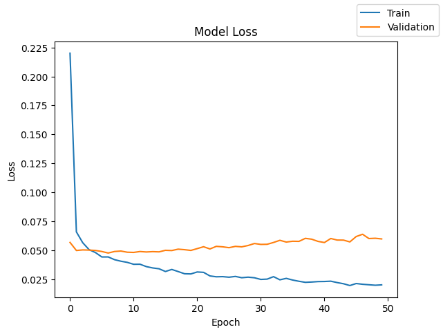

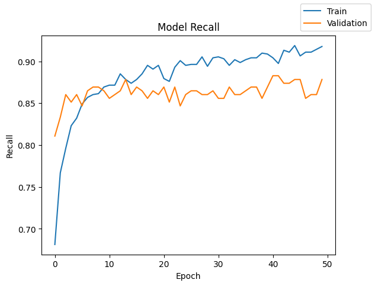

```python
# Plot learning curves
plot(history, 'loss')
plot(history, 'recall')
```